# Part 3 - Binary Classification

Zuliani Riccardo

17/1/2024

# 1 Load Libraries

```r
# installation of packages in case the user has not installed yet
requirements <- c("nnet", "MASS", "e1071", "class", "leaps", "glmnet", "car", "caTools",
              "pROC", "summarytools", "dplyr", "ggplot2", "tidyverse", "lubridate",
              "mapview", "sf", "geojsonio", "leaflet", "broom", "gridExtra",
              "effects")

for (req in requirements){
  if (!require(req, character.only = TRUE)){
      install.packages(req)
  }
}
```

```
##
##
##
##
##
##
##
##
##
##
##
##
##
## lattice theme set by effectsTheme()
## See ?effectsTheme for details.
```

# 2 Cast to a Binary Classification Task

As mentioned before, we decided, as the professor suggested, to cast our regression problem into a binary classification problem by splitting the range of possible time difference responses.

We will use the same responses of the Regression Section so first `inc_resp_min_qy` and then `emergency_min_qy`.

First things first load the cleaned train and test datasets.

```r
fire_data_clean.train <- read.csv("datasets/fire_data_clean.train.csv",
                                  stringsAsFactors = TRUE)
fire_data_clean.test <- read.csv("datasets/fire_data_clean.test.csv",
                                 stringsAsFactors = TRUE)

fire_data_clean.train$cong_dist <- as.factor(fire_data_clean.train$cong_dist)
fire_data_clean.test$cong_dist <- as.factor(fire_data_clean.test$cong_dist)

fire_data_clean <- rbind(fire_data_clean.train, fire_data_clean.test)

head(fire_data_clean)
```

```
##     inc_borough cong_dist al_source_desc al_index_desc highest_al_level
## 1      Brooklyn         7            EMS Initial Alarm      First Alarm
## 2        Queens         6        EMS-911 Initial Alarm      First Alarm
## 3         Bronx        14         Others Initial Alarm      First Alarm
## 4        Queens         5            EMS Initial Alarm      First Alarm
## 5 Staten Island        11        CLASS-3 Initial Alarm      First Alarm
## 6        Queens         7        EMS-911 Initial Alarm      First Alarm
##   inc_class_group inc_resp_min_qy engines_assigned ladders_assigned
## 1             M_E        6.316667                1                0
## 2             M_E        5.700000                1                0
## 3          NonM_E       10.550000                0                0
## 4             M_E        6.183333                1                0
## 5          NonM_E        4.366667                1                1
## 6             M_E        4.850000                1                0
##   others_units_assigned emergency_min_qy day_type working_hour time_of_day
## 1                     0        37.866667  Weekday         TRUE   Afternoon
## 2                     0        12.200000  Weekday         TRUE   Afternoon
## 3                     2        12.550000  Weekday         TRUE   Afternoon
## 4                     0         6.683333  Weekday         TRUE   Afternoon
## 5                     0         8.116667  Weekday         TRUE   Afternoon
## 6                     0        13.550000  Weekday         TRUE   Afternoon
##   tua_is_one
## 1       TRUE
## 2       TRUE
## 3      FALSE
## 4       TRUE
## 5      FALSE
## 6       TRUE
```

```r
dim(fire_data_clean)
```

```
## [1] 30726    15
```

Then we have to decide the range of value for both of response.

```r
summary(fire_data_clean$inc_resp_min_qy)
```

```
##    Min. 1st Qu.  Median    Mean 3rd Qu.    Max.
##   0.350   4.383   5.467   5.949   6.850  58.917
```

```r
summary(fire_data_clean$emergency_min_qy)
```

```
##    Min. 1st Qu.  Median    Mean 3rd Qu.    Max.
##    0.05    7.15   11.93   17.08   19.58  596.38
```

As responses threshold we decide to use the third quantile of both responses, thus:

```r
# threshold for inc_resp_min_qy
th_irm <- summary(fire_data_clean$inc_resp_min_qy)[5]

# threshold for emergency_min_qy
th_eme <- summary(fire_data_clean$emergency_min_qy)[5]
```

# 3 Range of inc_resp_min_qy as response

```r
# make a copy of the train and test
cl_resp_min_fd.train <- fire_data_clean.train
cl_resp_min_fd.test <- fire_data_clean.test

# set the factorial response via the early computed threshold
cl_resp_min_fd.train$fast_response <- cl_resp_min_fd.train$inc_resp_min_qy < th_irm
cl_resp_min_fd.test$fast_response <- cl_resp_min_fd.test$inc_resp_min_qy < th_irm

# remove the future time differences
cl_resp_min_fd.train <- cl_resp_min_fd.train %>% select(
  -c(emergency_min_qy, inc_resp_min_qy))

cl_resp_min_fd.test <- cl_resp_min_fd.test %>% select(
  -c(emergency_min_qy, inc_resp_min_qy))
```

See the summary of both train and test response.

```r
print(dfSummary(cl_resp_min_fd.train$fast_response,
                plain.ascii  = FALSE,
                style        = "multiline",
                headings     = FALSE,
                graph.magnif = 0.8,
                valid.col    = FALSE,
                na.col       = FALSE),
                method = 'render')
```

```
## cl_resp_min_fd.train$fast_response was converted to a data frame
```

**No**

**Variable**

**Stats / Values**

**Freqs (% of Valid)**

**Graph**

1

fast_response [logical]

| 1. FALSE |
| --- |
| 2. TRUE |

| 6157 | ( | 25.0% | ) |
| --- | --- | --- | --- |
| 18423 | ( | 75.0% | ) |

Generated by summarytools 1.0.1 ([R](https://www.r-project.org/) version 4.3.2)  
2024-01-25

```r
print(dfSummary(cl_resp_min_fd.test$fast_response,
                plain.ascii  = FALSE,
                style        = "multiline",
                headings     = FALSE,
                graph.magnif = 0.8,
                valid.col    = FALSE,
                na.col       = FALSE),
                method = 'render')
```

```
## cl_resp_min_fd.test$fast_response was converted to a data frame
```

**No**

**Variable**

**Stats / Values**

**Freqs (% of Valid)**

**Graph**

1

fast_response [logical]

| 1. FALSE |
| --- |
| 2. TRUE |

| 1569 | ( | 25.5% | ) |
| --- | --- | --- | --- |
| 4577 | ( | 74.5% | ) |

Generated by summarytools 1.0.1 ([R](https://www.r-project.org/) version 4.3.2)  
2024-01-25

As expected we have an unbalanced case, since exactly 3/4 of the train and test dataset have a fast response, whereas the rest have a low response.

## 3.1 Logistic Regression

Fit our full **Logistic Regression** model.

```r
res_glm.full <- glm(fast_response ~ ., data = cl_resp_min_fd.train,
                    family = "binomial")
summary(res_glm.full)
```

```
##
## Call:
## glm(formula = fast_response ~ ., family = "binomial", data = cl_resp_min_fd.train)
##
## Coefficients:
##                                 Estimate Std. Error z value Pr(>|z|)
## (Intercept)                     0.217781   0.224228   0.971 0.331425
## inc_boroughBrooklyn             0.776750   0.107131   7.250 4.15e-13 ***
## inc_boroughManhattan            0.273050   0.087967   3.104 0.001909 **
## inc_boroughQueens               0.078367   0.093429   0.839 0.401590
## inc_boroughStaten Island        0.748846   0.186332   4.019 5.85e-05 ***
## cong_dist5                      0.445024   0.132722   3.353 0.000799 ***
## cong_dist6                     -0.012547   0.136893  -0.092 0.926971
## cong_dist7                      0.238395   0.142415   1.674 0.094142 .
## cong_dist8                      0.118923   0.163171   0.729 0.466112
## cong_dist9                      0.038348   0.166378   0.230 0.817714
## cong_dist10                     0.212897   0.160089   1.330 0.183565
## cong_dist11                     0.070605   0.201737   0.350 0.726350
## cong_dist12                    -0.656343   0.167084  -3.928 8.56e-05 ***
## cong_dist13                     0.007398   0.159456   0.046 0.962997
## cong_dist14                    -0.320717   0.144122  -2.225 0.026060 *
## cong_dist15                    -0.047198   0.157242  -0.300 0.764053
## cong_dist16                    -0.432031   0.214149  -2.017 0.043650 *
## al_source_descEMS               0.285105   0.115252   2.474 0.013370 *
## al_source_descEMS-911           0.273591   0.116361   2.351 0.018712 *
## al_source_descOthers            0.233715   0.123951   1.886 0.059356 .
## al_source_descPHONE             0.026198   0.061095   0.429 0.668058
## al_index_descInitial Alarm      0.199643   0.063310   3.153 0.001614 **
## al_index_descOthers            -2.731923   1.140185  -2.396 0.016574 *
## highest_al_levelNonFirst Alarm  2.770781   1.496080   1.852 0.064022 .
## inc_class_groupM_MFAs           0.178458   0.226904   0.786 0.431579
## inc_class_groupNonM_E          -0.146100   0.103113  -1.417 0.156512
## inc_class_groupNonM_MFAs        0.077009   0.151440   0.509 0.611094
## inc_class_groupNonS_F           0.717486   0.192005   3.737 0.000186 ***
## inc_class_groupS_F              0.438289   0.159490   2.748 0.005995 **
## engines_assigned                0.420434   0.031114  13.513  < 2e-16 ***
## ladders_assigned               -0.030583   0.044995  -0.680 0.496702
## others_units_assigned           0.227875   0.040585   5.615 1.97e-08 ***
## day_typeWeekend                 0.128500   0.035865   3.583 0.000340 ***
## working_hourTRUE                0.373251   0.087761   4.253 2.11e-05 ***
## time_of_dayEvening              0.646274   0.098189   6.582 4.64e-11 ***
## time_of_dayMorning             -0.132503   0.041213  -3.215 0.001304 **
## time_of_dayNight               -0.011613   0.099767  -0.116 0.907337
## tua_is_oneTRUE                 -0.783984   0.064752 -12.108  < 2e-16 ***
## ---
## Signif. codes:  0 '***' 0.001 '**' 0.01 '*' 0.05 '.' 0.1 ' ' 1
##
## (Dispersion parameter for binomial family taken to be 1)
##
##     Null deviance: 27671  on 24579  degrees of freedom
## Residual deviance: 24627  on 24542  degrees of freedom
## AIC: 24703
##
## Number of Fisher Scoring iterations: 6
```

Let’s check if we have some **multicollinearity** problem using the `vif` function as we did on the previous analysis part.

```r
vif(res_glm.full)
```

```
##                             GVIF Df GVIF^(1/(2*Df))
## inc_borough           315.627264  4        2.053037
## cong_dist             331.234775 12        1.273520
## al_source_desc         15.925443  4        1.413388
## al_index_desc           3.630522  2        1.380360
## highest_al_level        2.187355  1        1.478971
## inc_class_group        17.590642  5        1.332073
## engines_assigned        2.028278  1        1.424176
## ladders_assigned        3.777378  1        1.943548
## others_units_assigned   1.824797  1        1.350850
## day_type                1.006458  1        1.003224
## working_hour            7.512752  1        2.740940
## time_of_day             7.632658  3        1.403178
## tua_is_one              3.540043  1        1.881500
```

```r
res_glm.clean <- update(res_glm.full, . ~ . - cong_dist - highest_al_level - inc_class_group - ladders_assigned , data = cl_resp_min_fd.train)
vif(res_glm.clean)
```

```
##                           GVIF Df GVIF^(1/(2*Df))
## inc_borough           1.039752  4        1.004885
## al_source_desc        2.371638  4        1.113989
## al_index_desc         1.114417  2        1.027453
## engines_assigned      1.827006  1        1.351668
## others_units_assigned 1.673787  1        1.293749
## day_type              1.004977  1        1.002485
## working_hour          7.517919  1        2.741882
## time_of_day           7.596682  3        1.402073
## tua_is_one            3.097255  1        1.759902
```

Let’s see the summary of the updated cleaned model.

```r
summary(res_glm.clean)
```

```
##
## Call:
## glm(formula = fast_response ~ inc_borough + al_source_desc +
##     al_index_desc + engines_assigned + others_units_assigned +
##     day_type + working_hour + time_of_day + tua_is_one, family = "binomial",
##     data = cl_resp_min_fd.train)
##
## Coefficients:
##                             Estimate Std. Error z value Pr(>|z|)
## (Intercept)                -0.003585   0.125600  -0.029 0.977229
## inc_boroughBrooklyn         1.035668   0.045331  22.847  < 2e-16 ***
## inc_boroughManhattan        0.173725   0.043676   3.978 6.96e-05 ***
## inc_boroughQueens           0.368978   0.046127   7.999 1.25e-15 ***
## inc_boroughStaten Island    0.953203   0.083766  11.379  < 2e-16 ***
## al_source_descEMS           0.373029   0.072250   5.163 2.43e-07 ***
## al_source_descEMS-911       0.350143   0.076199   4.595 4.33e-06 ***
## al_source_descOthers        0.248604   0.121847   2.040 0.041322 *
## al_source_descPHONE         0.026408   0.056933   0.464 0.642754
## al_index_descInitial Alarm  0.146317   0.052126   2.807 0.005001 **
## al_index_descOthers        -0.195545   0.747423  -0.262 0.793610
## engines_assigned            0.442464   0.029344  15.079  < 2e-16 ***
## others_units_assigned       0.214297   0.039071   5.485 4.14e-08 ***
## day_typeWeekend             0.126640   0.035585   3.559 0.000373 ***
## working_hourTRUE            0.356170   0.087186   4.085 4.40e-05 ***
## time_of_dayEvening          0.624457   0.097510   6.404 1.51e-10 ***
## time_of_dayMorning         -0.133055   0.040887  -3.254 0.001137 **
## time_of_dayNight           -0.019872   0.099080  -0.201 0.841039
## tua_is_oneTRUE             -0.738420   0.060145 -12.277  < 2e-16 ***
## ---
## Signif. codes:  0 '***' 0.001 '**' 0.01 '*' 0.05 '.' 0.1 ' ' 1
##
## (Dispersion parameter for binomial family taken to be 1)
##
##     Null deviance: 27671  on 24579  degrees of freedom
## Residual deviance: 24932  on 24561  degrees of freedom
## AIC: 24970
##
## Number of Fisher Scoring iterations: 6
```

Compare the **AIC** for the two models.

```r
AIC(res_glm.full, res_glm.clean) %>% arrange(AIC)
```

```
##               df      AIC
## res_glm.full  38 24702.89
## res_glm.clean 19 24969.86
```

Now we decide to update the previous model by adding the following interaction terms:

- `al_source_desc : engines_assigned`
- `al_source_desc : others_units_assigned`
- `day_type : working_hour`
- `time_of_day : tua_is_one`

```r
res_glm.clean.inter <- update(res_glm.clean, . ~ . +
                                al_source_desc : engines_assigned +
                                al_source_desc : others_units_assigned +
                                day_type : working_hour +
                                time_of_day : tua_is_one,
                              data = cl_resp_min_fd.train)
summary(res_glm.clean.inter)
```

```
##
## Call:
## glm(formula = fast_response ~ inc_borough + al_source_desc +
##     al_index_desc + engines_assigned + others_units_assigned +
##     day_type + working_hour + time_of_day + tua_is_one + al_source_desc:engines_assigned +
##     al_source_desc:others_units_assigned + day_type:working_hour +
##     time_of_day:tua_is_one, family = "binomial", data = cl_resp_min_fd.train)
##
## Coefficients:
##                                              Estimate Std. Error z value
## (Intercept)                                  0.381764   0.146132   2.612
## inc_boroughBrooklyn                          1.055582   0.045687  23.105
## inc_boroughManhattan                         0.175188   0.044188   3.965
## inc_boroughQueens                            0.362609   0.046482   7.801
## inc_boroughStaten Island                     0.953155   0.084153  11.326
## al_source_descEMS                            0.904979   0.193134   4.686
## al_source_descEMS-911                        0.919566   0.190708   4.822
## al_source_descOthers                        -0.027981   0.194556  -0.144
## al_source_descPHONE                         -0.648136   0.104988  -6.173
## al_index_descInitial Alarm                   0.160778   0.052330   3.072
## al_index_descOthers                         -0.376726   0.757297  -0.497
## engines_assigned                             0.021200   0.051972   0.408
## others_units_assigned                        0.428822   0.086733   4.944
## day_typeWeekend                             -0.104308   0.054671  -1.908
## working_hourTRUE                             0.266256   0.088815   2.998
## time_of_dayEvening                           0.871613   0.122937   7.090
## time_of_dayMorning                          -0.135495   0.072288  -1.874
## time_of_dayNight                             0.201418   0.122410   1.645
## tua_is_oneTRUE                              -0.493472   0.078017  -6.325
## al_source_descEMS:engines_assigned          -0.703302   0.166128  -4.233
## al_source_descEMS-911:engines_assigned      -0.720555   0.156904  -4.592
## al_source_descOthers:engines_assigned        0.859101   0.186056   4.617
## al_source_descPHONE:engines_assigned         0.664569   0.065306  10.176
## al_source_descEMS:others_units_assigned     -0.229233   0.127186  -1.802
## al_source_descEMS-911:others_units_assigned -0.291864   0.140016  -2.085
## al_source_descOthers:others_units_assigned  -0.756124   0.114072  -6.628
## al_source_descPHONE:others_units_assigned   -0.280501   0.100742  -2.784
## day_typeWeekend:working_hourTRUE             0.414920   0.072651   5.711
## time_of_dayEvening:tua_is_oneTRUE           -0.308335   0.100521  -3.067
## time_of_dayMorning:tua_is_oneTRUE            0.004234   0.085768   0.049
```

[output cut: 28 more lines]

```
## al_source_descPHONE:others_units_assigned    0.00536 **
## day_typeWeekend:working_hourTRUE            1.12e-08 ***
## time_of_dayEvening:tua_is_oneTRUE            0.00216 **
## time_of_dayMorning:tua_is_oneTRUE            0.96063
## time_of_dayNight:tua_is_oneTRUE              0.00700 **
## ---
## Signif. codes:  0 '***' 0.001 '**' 0.01 '*' 0.05 '.' 0.1 ' ' 1
##
## (Dispersion parameter for binomial family taken to be 1)
##
##     Null deviance: 27671  on 24579  degrees of freedom
## Residual deviance: 24604  on 24549  degrees of freedom
## AIC: 24666
##
## Number of Fisher Scoring iterations: 6
```

Regarding the interaction terms that we have added we note that:

- The interaction between `al_source_desc` and `engines_assigned` is strongly significant for all the cases.
- `al_source_desc` between `others_units_assigned` is significant for many cases, but for others like **EMS** is poorly significant.
- `time_of_day` between `tua_is_one` is significant except for the **Morning** category.
- `day_type` between `working_hour` is strongly significant.

```r
AIC(res_glm.full, res_glm.clean, res_glm.clean.inter) %>% arrange(AIC)
```

```
##                     df      AIC
## res_glm.clean.inter 31 24666.07
## res_glm.full        38 24702.89
## res_glm.clean       19 24969.86
```

And by looking at the **AIC** we can say that this model is better than the initial full model.

Now to have a complete comparison we decided to add the same interaction terms to the initial full model.

```r
res_glm.full.inter <- update(res_glm.full, . ~ . +
                               al_source_desc : engines_assigned +
                               al_source_desc : others_units_assigned +
                               day_type : working_hour +
                               time_of_day : tua_is_one,
                             data = cl_resp_min_fd.train)
summary(res_glm.full.inter)
```

```
##
## Call:
## glm(formula = fast_response ~ inc_borough + cong_dist + al_source_desc +
##     al_index_desc + highest_al_level + inc_class_group + engines_assigned +
##     ladders_assigned + others_units_assigned + day_type + working_hour +
##     time_of_day + tua_is_one + al_source_desc:engines_assigned +
##     al_source_desc:others_units_assigned + day_type:working_hour +
##     time_of_day:tua_is_one, family = "binomial", data = cl_resp_min_fd.train)
##
## Coefficients:
##                                             Estimate Std. Error z value
## (Intercept)                                  0.15828    0.23664   0.669
## inc_boroughBrooklyn                          0.81571    0.10784   7.564
## inc_boroughManhattan                         0.26757    0.08857   3.021
## inc_boroughQueens                            0.11791    0.09417   1.252
## inc_boroughStaten Island                     0.78210    0.18713   4.179
## cong_dist5                                   0.42026    0.13290   3.162
## cong_dist6                                  -0.01700    0.13713  -0.124
## cong_dist7                                   0.23955    0.14274   1.678
## cong_dist8                                   0.13487    0.16365   0.824
## cong_dist9                                   0.05270    0.16682   0.316
## cong_dist10                                  0.20439    0.16058   1.273
## cong_dist11                                  0.08076    0.20231   0.399
## cong_dist12                                 -0.61632    0.16778  -3.673
## cong_dist13                                  0.05649    0.16005   0.353
## cong_dist14                                 -0.32748    0.14448  -2.267
## cong_dist15                                 -0.01573    0.15790  -0.100
## cong_dist16                                 -0.40938    0.21599  -1.895
## al_source_descEMS                            1.06950    0.22202   4.817
## al_source_descEMS-911                        1.15951    0.22692   5.110
## al_source_descOthers                        -0.02039    0.20082  -0.102
## al_source_descPHONE                         -0.75200    0.11837  -6.353
## al_index_descInitial Alarm                   0.20428    0.06358   3.213
## al_index_descOthers                         -3.17437    1.16458  -2.726
## highest_al_levelNonFirst Alarm               2.96434    1.52021   1.950
## inc_class_groupM_MFAs                        0.23598    0.22717   1.039
## inc_class_groupNonM_E                        0.11211    0.10670   1.051
## inc_class_groupNonM_MFAs                     0.35125    0.15468   2.271
## inc_class_groupNonS_F                        0.93125    0.19525   4.769
## inc_class_groupS_F                           0.59936    0.16397   3.655
```

[output cut: 67 more lines]

```
## al_source_descPHONE:others_units_assigned   0.000215 ***
## day_typeWeekend:working_hourTRUE            3.44e-08 ***
## time_of_dayEvening:tua_is_oneTRUE           0.001187 **
## time_of_dayMorning:tua_is_oneTRUE           0.850426
## time_of_dayNight:tua_is_oneTRUE             0.002194 **
## ---
## Signif. codes:  0 '***' 0.001 '**' 0.01 '*' 0.05 '.' 0.1 ' ' 1
##
## (Dispersion parameter for binomial family taken to be 1)
##
##     Null deviance: 27671  on 24579  degrees of freedom
## Residual deviance: 24315  on 24530  degrees of freedom
## AIC: 24415
##
## Number of Fisher Scoring iterations: 7
```

```r
AIC(res_glm.full, res_glm.full.inter, res_glm.clean, res_glm.clean.inter) %>%
  arrange(AIC)
```

```
##                     df      AIC
## res_glm.full.inter  50 24415.50
## res_glm.clean.inter 31 24666.07
## res_glm.full        38 24702.89
## res_glm.clean       19 24969.86
```

It seems like that the full model with the interaction terms outperform the other specified models, later we will see if this statement holds or not during predictions.

## 3.2 Model Interpretation

We decide to interpret the model with the lower AIC, so the **res_glm.full.inter** which has $24415.50$ as AIC.

For interpreting the specified model we decide to use the library `effect`. Let’s recall the summary of the model, and see the effects of some strongly significant predictors.

```r
summary(res_glm.full.inter)
```

```
##
## Call:
## glm(formula = fast_response ~ inc_borough + cong_dist + al_source_desc +
##     al_index_desc + highest_al_level + inc_class_group + engines_assigned +
##     ladders_assigned + others_units_assigned + day_type + working_hour +
##     time_of_day + tua_is_one + al_source_desc:engines_assigned +
##     al_source_desc:others_units_assigned + day_type:working_hour +
##     time_of_day:tua_is_one, family = "binomial", data = cl_resp_min_fd.train)
##
## Coefficients:
##                                             Estimate Std. Error z value
## (Intercept)                                  0.15828    0.23664   0.669
## inc_boroughBrooklyn                          0.81571    0.10784   7.564
## inc_boroughManhattan                         0.26757    0.08857   3.021
## inc_boroughQueens                            0.11791    0.09417   1.252
## inc_boroughStaten Island                     0.78210    0.18713   4.179
## cong_dist5                                   0.42026    0.13290   3.162
## cong_dist6                                  -0.01700    0.13713  -0.124
## cong_dist7                                   0.23955    0.14274   1.678
## cong_dist8                                   0.13487    0.16365   0.824
## cong_dist9                                   0.05270    0.16682   0.316
## cong_dist10                                  0.20439    0.16058   1.273
## cong_dist11                                  0.08076    0.20231   0.399
## cong_dist12                                 -0.61632    0.16778  -3.673
## cong_dist13                                  0.05649    0.16005   0.353
## cong_dist14                                 -0.32748    0.14448  -2.267
## cong_dist15                                 -0.01573    0.15790  -0.100
## cong_dist16                                 -0.40938    0.21599  -1.895
## al_source_descEMS                            1.06950    0.22202   4.817
## al_source_descEMS-911                        1.15951    0.22692   5.110
## al_source_descOthers                        -0.02039    0.20082  -0.102
## al_source_descPHONE                         -0.75200    0.11837  -6.353
## al_index_descInitial Alarm                   0.20428    0.06358   3.213
## al_index_descOthers                         -3.17437    1.16458  -2.726
## highest_al_levelNonFirst Alarm               2.96434    1.52021   1.950
## inc_class_groupM_MFAs                        0.23598    0.22717   1.039
## inc_class_groupNonM_E                        0.11211    0.10670   1.051
## inc_class_groupNonM_MFAs                     0.35125    0.15468   2.271
## inc_class_groupNonS_F                        0.93125    0.19525   4.769
## inc_class_groupS_F                           0.59936    0.16397   3.655
```

[output cut: 67 more lines]

```
## al_source_descPHONE:others_units_assigned   0.000215 ***
## day_typeWeekend:working_hourTRUE            3.44e-08 ***
## time_of_dayEvening:tua_is_oneTRUE           0.001187 **
## time_of_dayMorning:tua_is_oneTRUE           0.850426
## time_of_dayNight:tua_is_oneTRUE             0.002194 **
## ---
## Signif. codes:  0 '***' 0.001 '**' 0.01 '*' 0.05 '.' 0.1 ' ' 1
##
## (Dispersion parameter for binomial family taken to be 1)
##
##     Null deviance: 27671  on 24579  degrees of freedom
## Residual deviance: 24315  on 24530  degrees of freedom
## AIC: 24415
##
## Number of Fisher Scoring iterations: 7
```

We analyse the effects of the following predictors: `inc_borough`, `inc_class_group`, `others_units_assigned`, and `al_source_desc`.

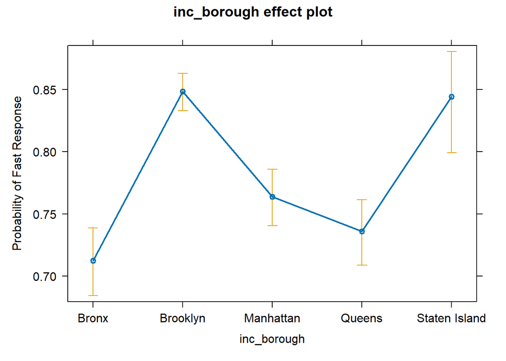

```r
plot( effect("inc_borough", res_glm.full.inter), rescale.axis = FALSE,
      ylab = "Probability of Fast Response")
```

The lower probability of having a fast response is for The **Bronx**, whereas the higher are in the borough of **Brooklyn** and **Staten Island**, with the difference that the first has a smaller confidence interval respect to the second.

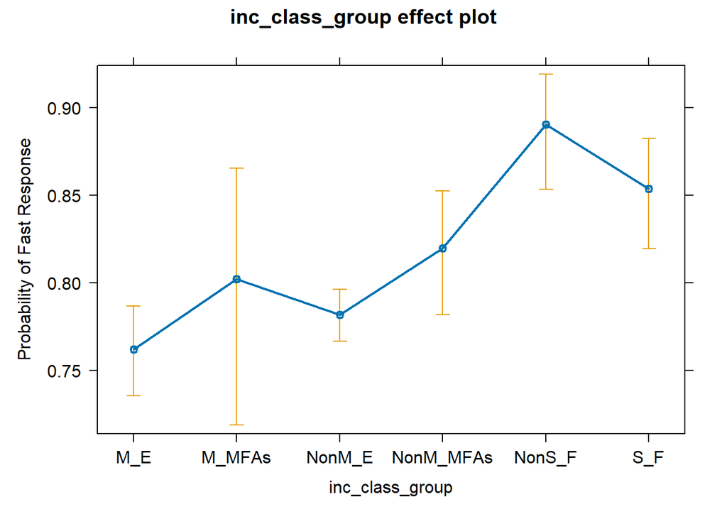

```r
plot(effect("inc_class_group", res_glm.full.inter), rescale.axis = FALSE,
     ylab = "Probability of Fast Response")
```

As expected we have higher probability to have a fast response for the **Fire** and **NonFire Emergencies** incident and lower for **Medical Emergencies** and **Medical MFAs**.

```
## NOTE: others_units_assigned is not a high-order term in the model
```

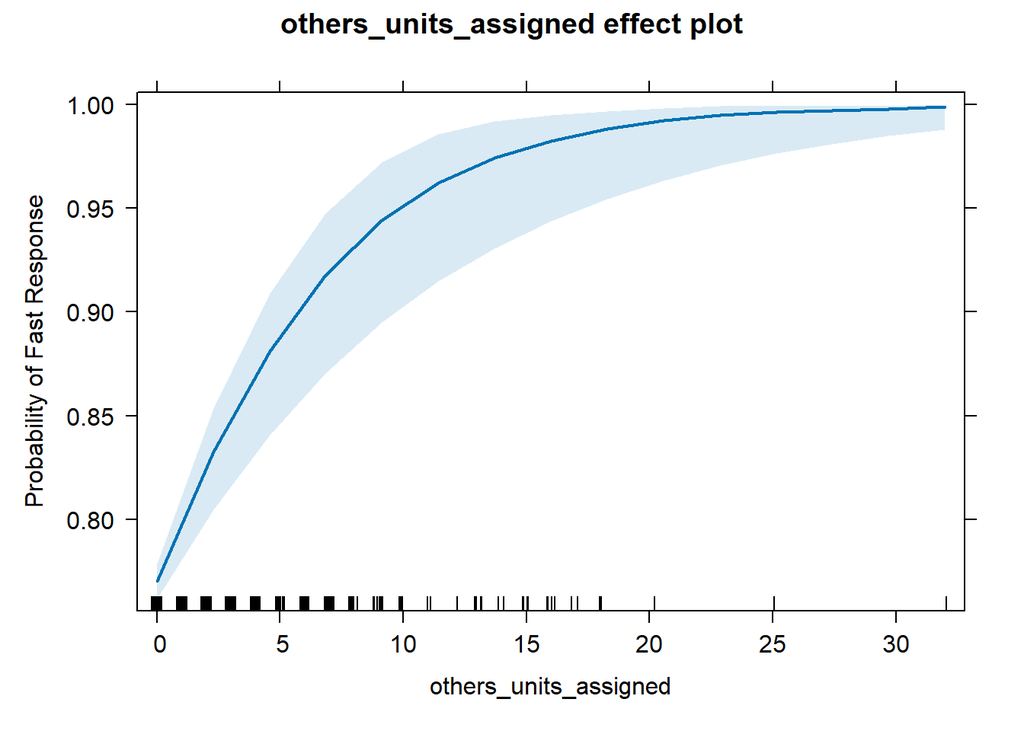

```r
plot(effect("others_units_assigned", res_glm.full.inter), rescale.axis = FALSE,
     ylab = "Probability of Fast Response")
```

Interestingly we can see that the **others_units_assigned** follow a logarithmic curve.

```
## NOTE: al_source_desc is not a high-order term in the model
```

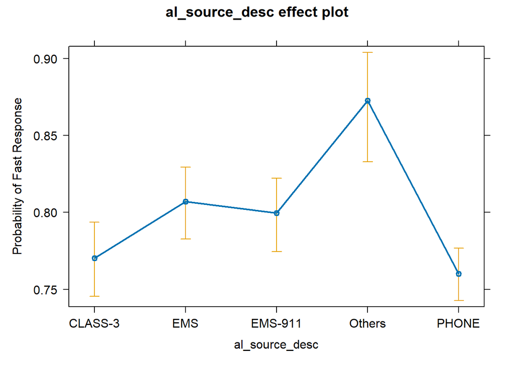

```r
plot(effect("al_source_desc", res_glm.full.inter), rescale.axis = FALSE,
     ylab = "Probability of Fast Response")
```

We can see that there is an higher probability of having a fast response if the incident has origin from the **Others** category, the one that we used to merge the categries that have low frequency. Whereas the lower probability respect the possible case of have a fast response is from the **Phone** category.

Let’s the effect from a the interaction of `time_of_day` and `tua_is_one`.

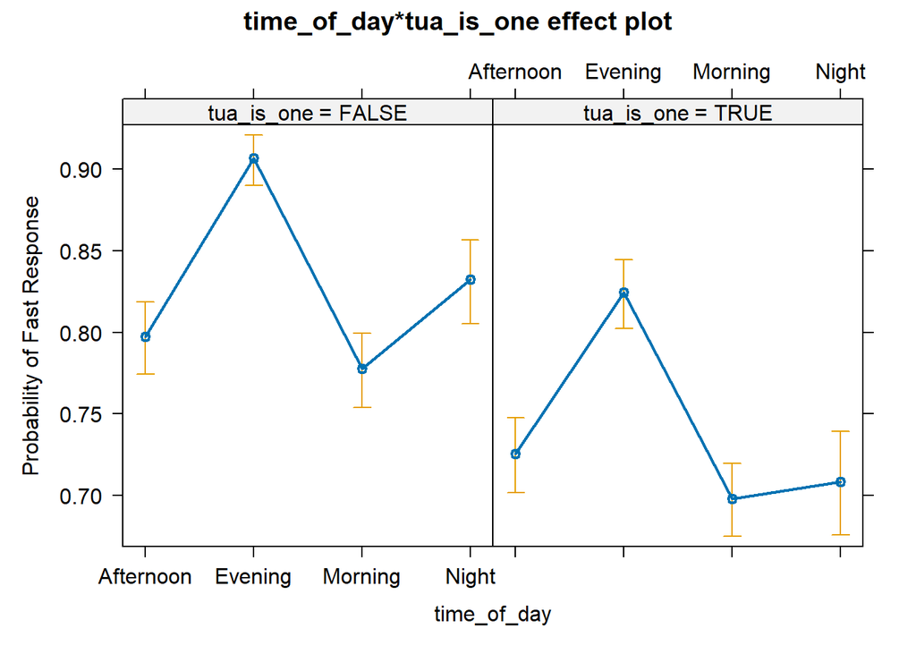

```r
plot(effect("time_of_day:tua_is_one", res_glm.full.inter), rescale.axis=FALSE, ylab="Probability of Fast Response")
```

We can see that in the case of having more than a single unit assigned we have a higher probability in the Evening of having a fast response, similarly in the case of having a single assigned unit. Interestingly we can see that the two line plots are pretty similar, they are only vertically scaled.

## 3.3 Model Comparison

Now we see if what the *AIC* suggest to us is correct in practice or not by doing predictions on the test dataset.

```r
res_glm.full.pred <- predict(res_glm.full, newdata = cl_resp_min_fd.test,
                             type = "response")

res_glm.full.inter.pred <- predict(res_glm.full.inter,
                              newdata = cl_resp_min_fd.test, type = "response")

res_glm.clean.pred <- predict(res_glm.clean, newdata = cl_resp_min_fd.test,
                              type = "response")

res_glm.clean.inter.pred <- predict(res_glm.clean.inter,
                              newdata = cl_resp_min_fd.test, type = "response")
```

At this point we use the `pROC` library in order to extrapolate the best threshold using the function `roc`.

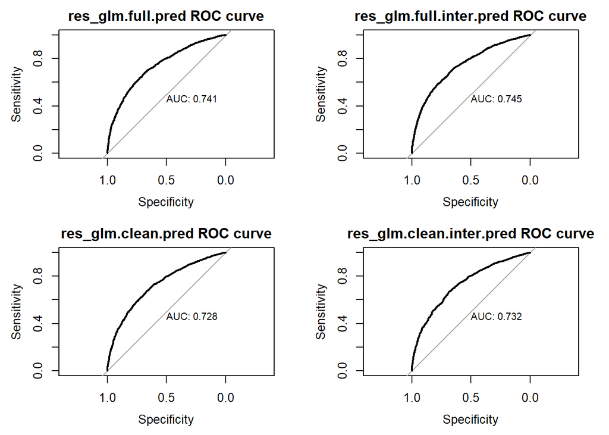

```r
par(mfrow=c(2,2))

res_glm.full.roc <- roc(
  cl_resp_min_fd.test$fast_response ~ res_glm.full.pred, plot = TRUE,
  print.auc = TRUE, main = "res_glm.full.pred ROC curve")
res_glm.full.inter.roc <- roc(
  cl_resp_min_fd.test$fast_response ~ res_glm.full.inter.pred, print.auc = TRUE,
  plot = TRUE, main = "res_glm.full.inter.pred ROC curve")
res_glm.clean.roc <- roc(
  cl_resp_min_fd.test$fast_response ~ res_glm.clean.pred, plot = TRUE
  , print.auc = TRUE, main = "res_glm.clean.pred ROC curve")
res_glm.clean.inter.roc <- roc(
  cl_resp_min_fd.test$fast_response ~ res_glm.clean.inter.pred,
  print.auc = TRUE, plot = TRUE, main = "res_glm.clean.inter.pred ROC curve")
```

By the plots we can see that the Area Under the Curve (AUC) computed by the ROC curves gives almost the same results.

Now we extract from each `roc` object the best threshold in order to use it during predictions.

```r
res_glm.full.roc.bmetrics <- coords(res_glm.full.roc, x = "best", ret = "all")

res_glm.full.inter.roc.bmetrics <- coords(res_glm.full.inter.roc, x = "best",
                                          ret = "all")

res_glm.clean.roc.bmetrics <- coords(res_glm.clean.roc, x = "best", ret = "all")

res_glm.clean.inter.roc.bmetrics <- coords(res_glm.clean.inter.roc, x = "best",
                                           ret = "all")
```

Rename the single row for each dataframe and concatenate all in a single one.

```r
row.names(res_glm.full.roc.bmetrics) <- "Full Model"

row.names(res_glm.full.inter.roc.bmetrics) <- "Interaction Full Model"

row.names(res_glm.clean.roc.bmetrics) <- "Cleaned Model"

row.names(res_glm.clean.inter.roc.bmetrics) <- "Interaction Cleaned Model"

res_results <- rbind(res_glm.full.roc.bmetrics, res_glm.full.inter.roc.bmetrics,
                  res_glm.clean.roc.bmetrics, res_glm.clean.inter.roc.bmetrics)
```

Now we make a comparisons result:

1. **Specificity**

```r
res_results %>% select(specificity) %>% arrange(desc(specificity))
```

```
##                           specificity
## Interaction Full Model      0.7928617
## Interaction Cleaned Model   0.6889739
## Full Model                  0.6806883
## Cleaned Model               0.6704908
```

In terms of specificity the best model is the **Interaction Full Model**.

2. **Sensitivity**

```r
res_results %>% select(sensitivity) %>% arrange(desc(sensitivity))
```

```
##                           sensitivity
## Full Model                  0.6849465
## Cleaned Model               0.6722744
## Interaction Cleaned Model   0.6672493
## Interaction Full Model      0.5754861
```

Regarding the sensitivity the best model is the **Full Model**.

3. **Accuracy**

```r
res_results %>% select(accuracy) %>% arrange(desc(accuracy))
```

```
##                            accuracy
## Full Model                0.6838594
## Interaction Cleaned Model 0.6727953
## Cleaned Model             0.6718191
## Interaction Full Model    0.6309795
```

And finally for the accuracy measure the best model is the **Full Model**.

However we recall that we have an unbalanced case and for this reason model choice should happen on the one that is able to correctly classify fast response time incidents of true fast response incidents.

Recalling that the sensitivity is the ratio of how many fast response emergencies we have detected that are actually fast. So since we have an unbalanced dataset with 3/4 of the observations from the train and test dataset that are fast emergencies we choose the **Full Model** since it has the highest **sensitivity** and with specificity not worse than a random choice.

Let’s have a quick look at the confusion matrix for the four models that we have specified.

1- **Full Model**

```r
table(preds=(res_glm.full.pred > res_glm.full.roc.bmetrics$threshold),
      true=as.logical(cl_resp_min_fd.test$fast_response))
```

```
##        true
## preds   FALSE TRUE
##   FALSE  1068 1442
##   TRUE    501 3135
```

2- **Interaction Full Model**

```r
table(preds=(res_glm.full.inter.pred > res_glm.full.inter.roc.bmetrics$threshold),
      true=as.logical(cl_resp_min_fd.test$fast_response))
```

```
##        true
## preds   FALSE TRUE
##   FALSE  1244 1943
##   TRUE    325 2634
```

3- **Cleaned Model**

```r
table(preds=(res_glm.clean.pred > res_glm.clean.roc.bmetrics$threshold),
      true=as.logical(cl_resp_min_fd.test$fast_response))
```

```
##        true
## preds   FALSE TRUE
##   FALSE  1052 1500
##   TRUE    517 3077
```

4- **Interaction Cleaned Model**

```r
table(preds=(res_glm.clean.inter.pred > res_glm.clean.inter.roc.bmetrics$threshold),
      true=as.logical(cl_resp_min_fd.test$fast_response))
```

```
##        true
## preds   FALSE TRUE
##   FALSE  1081 1523
##   TRUE    488 3054
```

Now we decide to shrink the latter model by running **Ridge Regression** and **Lasso Regression**.

## 3.4 Ridge Shrinkage Estimation

We decide to use the full model with interaction terms in order to see how the ridge is able to shrink the coefficients.

We recall that the penalty on ridge is put in the sum of squares of the coefficients thus shrinking the model coefficient toward zero by the parameter $\lambda$.

So first of all we have to create our model matrices.

```r
# model matrix for train
x_train <- model.matrix(formula(res_glm.full.inter), data = cl_resp_min_fd.train)
y_train <- cl_resp_min_fd.train$fast_response

# mode matrix for test
x_test <- model.matrix(formula(res_glm.full.inter), data = cl_resp_min_fd.test)
y_test <- cl_resp_min_fd.test$fast_response
```

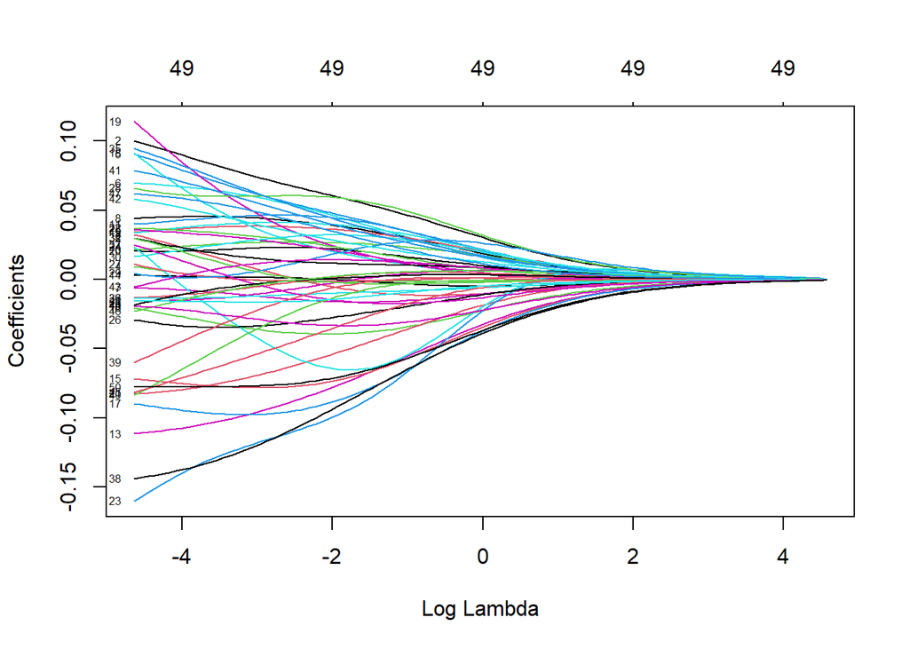

```r
res_fit.ridge <- glmnet(x_train, y_train, familiy = "binomial", alpha = 0)
plot(res_fit.ridge, xvar = "lambda", label = TRUE)
```

Choose the best value of lambda via cross-validation.

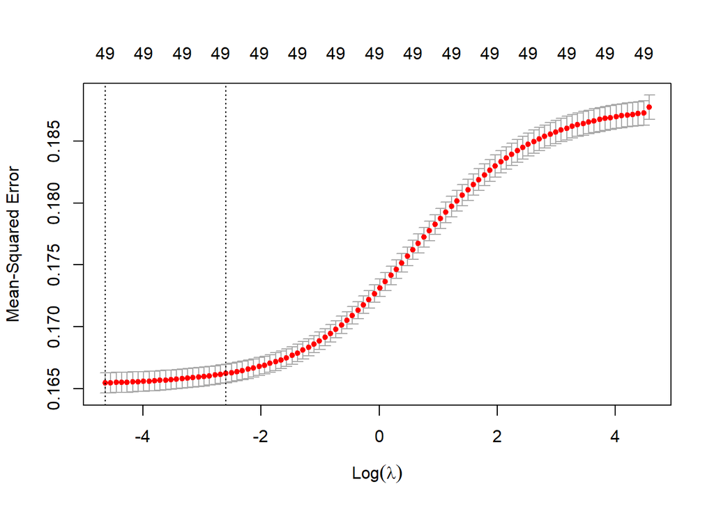

```r
res_cv.ridge <- cv.glmnet(x_train, y_train, familiy = "binomial", alpha = 0)
plot(res_cv.ridge)
```

The value of $\lambda$ that minimises the ridge cross-validated mean square error is:

```r
res_cv.ridge$lambda.min
```

```
## [1] 0.009678501
```

However, empirical experience suggests to select the simplest model whose $\lambda$ value is within one standard error from the minimum of the cross-validated mean square error:

```r
res_bestlam.ridge <- res_cv.ridge$lambda.1se
res_bestlam.ridge
```

```
## [1] 0.07493712
```

However, empirical experience suggests to select the simplest model whose $\lambda$ value is within one standard error from the minimum of the cross-validated mean square error:

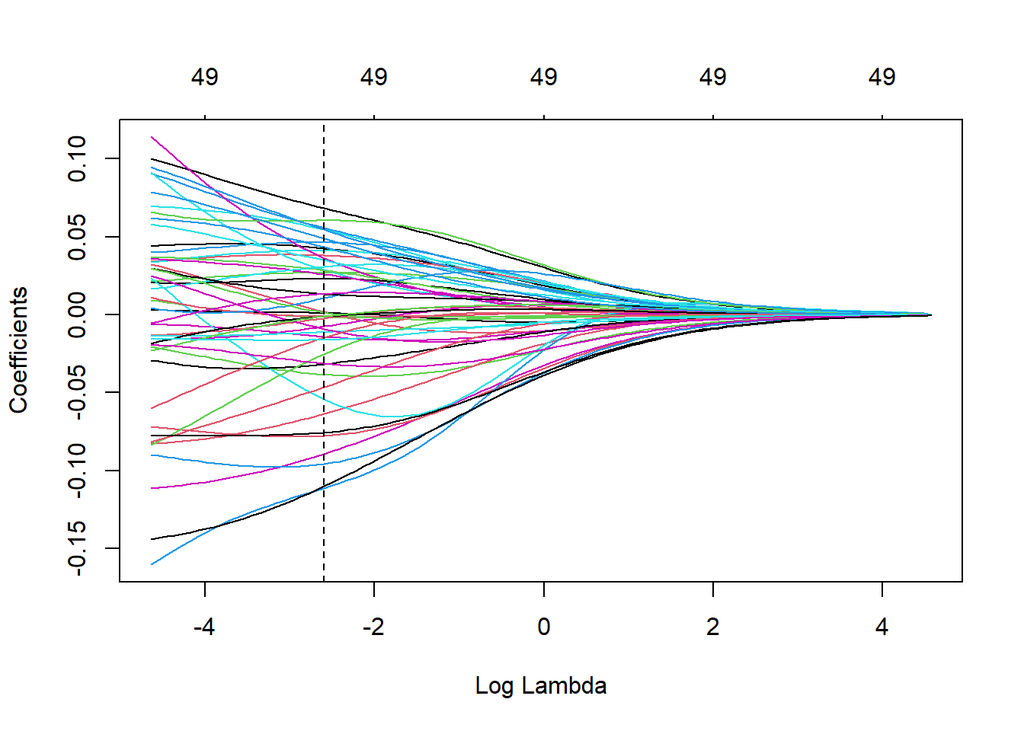

```r
plot(res_fit.ridge, xvar = "lambda")
abline(v = log(res_bestlam.ridge), lwd = 1.2, lty = "dashed")
```

These are the coefficients:

```r
coef(res_fit.ridge,  s=res_bestlam.ridge)
```

```
## 51 x 1 sparse Matrix of class "dgCMatrix"
##                                                        s1
## (Intercept)                                  0.7460235494
## (Intercept)                                  .
## inc_boroughBrooklyn                          0.0682626562
## inc_boroughManhattan                         0.0017260612
## inc_boroughQueens                           -0.0016055173
## inc_boroughStaten Island                     0.0556238628
## cong_dist5                                   0.0545661989
## cong_dist6                                  -0.0140209374
## cong_dist7                                   0.0427139732
## cong_dist8                                   0.0379859538
## cong_dist9                                   0.0269533452
## cong_dist10                                  0.0463589171
## cong_dist11                                  0.0410991272
## cong_dist12                                 -0.0893222699
## cong_dist13                                  0.0010752237
## cong_dist14                                 -0.0776945372
## cong_dist15                                 -0.0383828371
## cong_dist16                                 -0.0957258028
## al_source_descEMS                            0.0286418423
## al_source_descEMS-911                        0.0363266226
## al_source_descOthers                         0.0230874189
## al_source_descPHONE                         -0.0635243811
## al_index_descInitial Alarm                   0.0284345644
## al_index_descOthers                         -0.1111867379
## highest_al_levelNonFirst Alarm              -0.0542265050
## inc_class_groupM_MFAs                        0.0258986251
## inc_class_groupNonM_E                       -0.0315974402
## inc_class_groupNonM_MFAs                    -0.0011287799
## inc_class_groupNonS_F                        0.0604069206
## inc_class_groupS_F                           0.0107651032
## engines_assigned                             0.0308787331
## ladders_assigned                            -0.0075598844
## others_units_assigned                        0.0132268314
## day_typeWeekend                             -0.0022978073
## working_hourTRUE                             0.0014579951
## time_of_dayEvening                           0.0545233115
## time_of_dayMorning                          -0.0111893766
## time_of_dayNight                            -0.0091846632
## tua_is_oneTRUE                              -0.1099036428
## al_source_descEMS:engines_assigned          -0.0147274965
## al_source_descEMS-911:engines_assigned      -0.0252084600
## al_source_descOthers:engines_assigned        0.0487422009
## al_source_descPHONE:engines_assigned         0.0349286147
## al_source_descEMS:others_units_assigned      0.0133969445
## al_source_descEMS-911:others_units_assigned -0.0011449839
## al_source_descOthers:others_units_assigned  -0.0464431926
## al_source_descPHONE:others_units_assigned   -0.0009659789
## day_typeWeekend:working_hourTRUE             0.0433655501
## time_of_dayEvening:tua_is_oneTRUE           -0.0160829209
## time_of_dayMorning:tua_is_oneTRUE           -0.0312901996
## time_of_dayNight:tua_is_oneTRUE             -0.0756572916
```

We make the prediction on the test set.

```r
res_fit.ridge.pred <- predict(res_fit.ridge, s = res_bestlam.ridge,
                              newx = x_test, type = "response")
```

Apply the `roc` function in order to get the best threshold value.

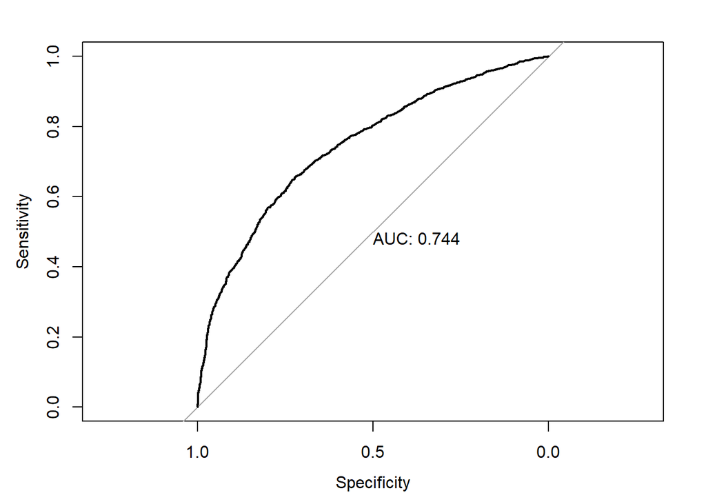

```r
res_fit.ridge.roc <- roc(y_test ~ res_fit.ridge.pred, plot = TRUE,
                         print.auc = TRUE)
```

See the result:

```r
res_fit.ridge.roc.bmetrics <- coords(res_fit.ridge.roc, x="best", ret="all")
res_fit.ridge.roc.bmetrics
```

```
##           threshold specificity sensitivity  accuracy   tn   tp   fn  fp
## threshold 0.7290678   0.7214786   0.6567621 0.6732834 1132 3006 1571 437
##                 npv       ppv       fdr       fpr       tpr       tnr       fnr
## threshold 0.4187939 0.8730758 0.1269242 0.2785214 0.6567621 0.7214786 0.3432379
##           1-specificity 1-sensitivity 1-accuracy     1-npv     1-ppv precision
## threshold     0.2785214     0.3432379  0.3267166 0.5812061 0.1269242 0.8730758
##              recall   youden closest.topleft
## threshold 0.6567621 1.378241       0.1953864
```

See the confusion matrix using the best threshold value.

```r
table(preds=(res_fit.ridge.pred > res_fit.ridge.roc.bmetrics$threshold), true=as.logical(cl_resp_min_fd.test$fast_response))
```

```
##        true
## preds   FALSE TRUE
##   FALSE  1132 1571
##   TRUE    437 3006
```

Concatenate with the other results.

```r
row.names(res_fit.ridge.roc.bmetrics) <- "Inteaction Full Moldel Ridge"
res_results <- rbind(res_results, res_fit.ridge.roc.bmetrics)
```

## 3.5 Lasso Shrinkage Estimation

Now is the turn of lasso and we decide to use the full model with interaction for the same reason as ridge.

In Lasso instead of the sum of squares of the coefficients we penalize the sum of absolute value of the coefficients.

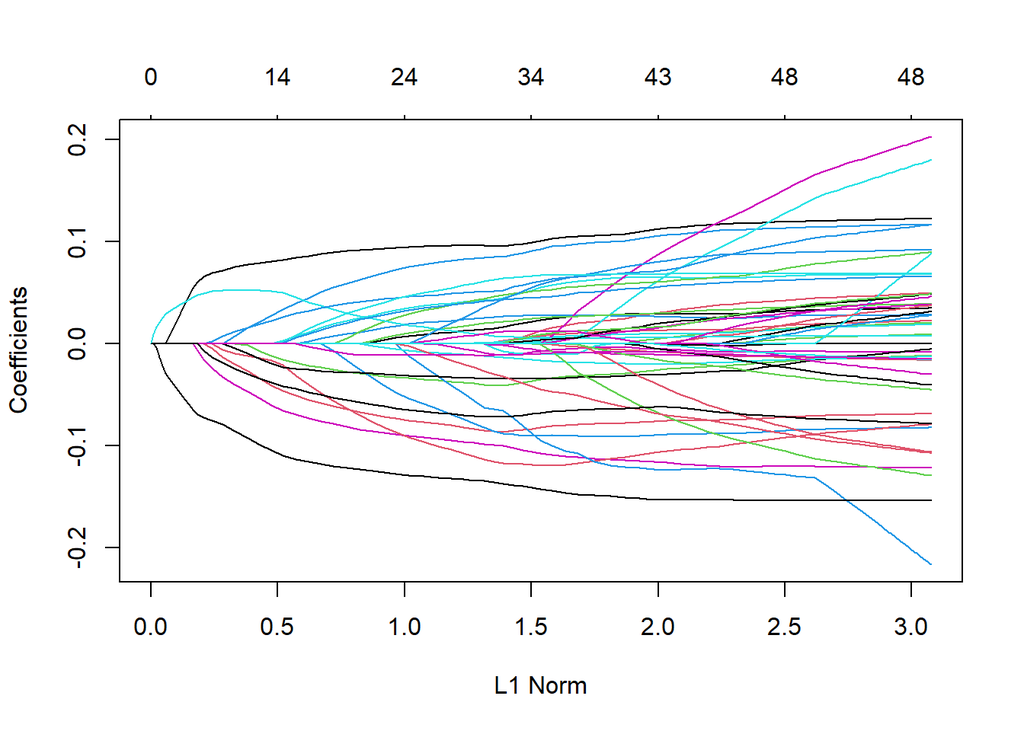

```r
res_fit.lasso <- glmnet(x_train, y_train, familiy="binomial", alpha = 1)
plot(res_fit.lasso)
```

Again choose the best lambda via cross-validation.

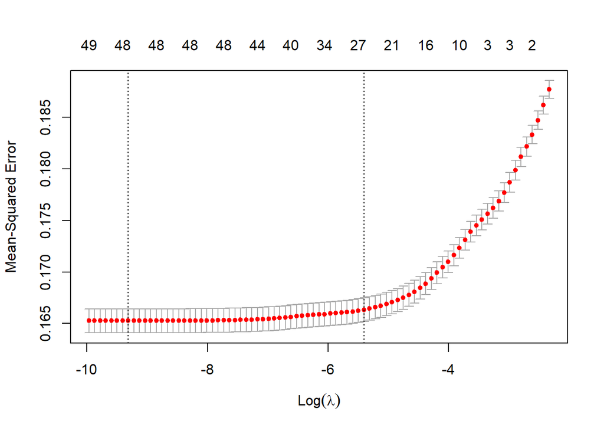

```r
res_cv.lasso <- cv.glmnet(x_train, y_train, familiy="binomial", alpha = 1)
plot(res_cv.lasso)
```

```r
res_cv.lasso$lambda.min
```

```
## [1] 9.026203e-05
```

Again like before we take as $\lambda$ value corresponding to one standard error from the minimum of the cross-validated mean square error:

```r
res_bestlam.lasso <- res_cv.lasso$lambda.1se
res_bestlam.lasso
```

```
## [1] 0.004492362
```

Like before, now visualize again the lasso estimates as a function of the logarithm of $\lambda$ and add a vertical line corresponding to **best.lambda**:

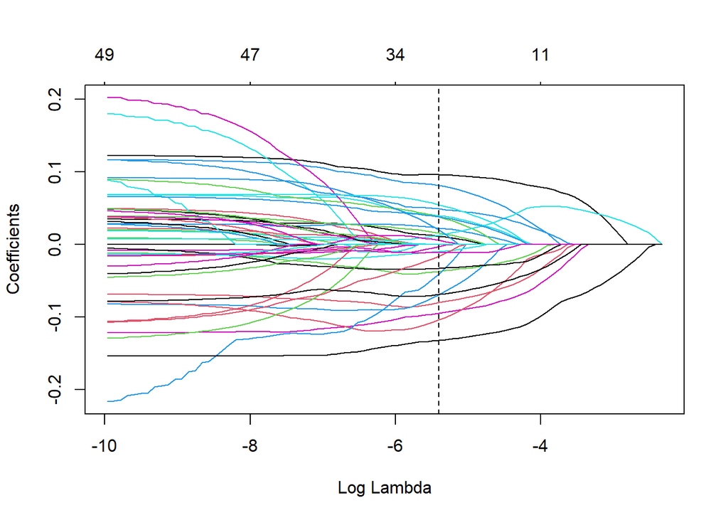

```r
plot(res_fit.lasso, xvar = "lambda")
abline(v = log(res_bestlam.lasso), lwd = 1.2, lty = "dashed")
```

These are the coefficients:

```r
res_bestlam.lasso.coef <- coef(res_fit.lasso,  s=res_bestlam.lasso)

res_bestlam.lasso.coef[res_bestlam.lasso.coef[,1]!=0,]
```

```
##                                (Intercept)
##                                0.804152999
##                        inc_boroughBrooklyn
##                                0.095885435
##                   inc_boroughStaten Island
##                                0.081323486
##                                 cong_dist5
##                                0.039878293
##                                 cong_dist6
##                               -0.003230621
##                                 cong_dist7
##                                0.011417650
##                                cong_dist10
##                                0.022758438
##                                cong_dist12
##                               -0.094335021
##                                cong_dist14
##                               -0.079999348
##                                cong_dist15
##                               -0.036917303
##                                cong_dist16
##                               -0.069379618
##                        al_source_descPHONE
##                               -0.103629019
##                 al_index_descInitial Alarm
##                                0.015863100
##                        al_index_descOthers
##                               -0.040612513
##                      inc_class_groupNonM_E
##                               -0.032844715
##                      inc_class_groupNonS_F
##                                0.037856469
##                           engines_assigned
##                                0.012867179
##                         time_of_dayEvening
##                                0.048995939
##                         time_of_dayMorning
##                               -0.009662450
##                             tua_is_oneTRUE
##                               -0.131992959
##      al_source_descOthers:engines_assigned
##                                0.020073148
##       al_source_descPHONE:engines_assigned
##                                0.054829166
##    al_source_descEMS:others_units_assigned
##                                0.005702880
## al_source_descOthers:others_units_assigned
##                               -0.016056814
##           day_typeWeekend:working_hourTRUE
##                                0.038042641
##          time_of_dayMorning:tua_is_oneTRUE
##                               -0.011214583
##            time_of_dayNight:tua_is_oneTRUE
##                               -0.068629351
```

Now we apply prediction on the test set.

```r
res_fit.lasso.pred <- predict(res_fit.lasso, s = res_bestlam.lasso,
                              newx = x_test, type = "response")
```

Then we apply the `roc` function to obtain the best threshold value.

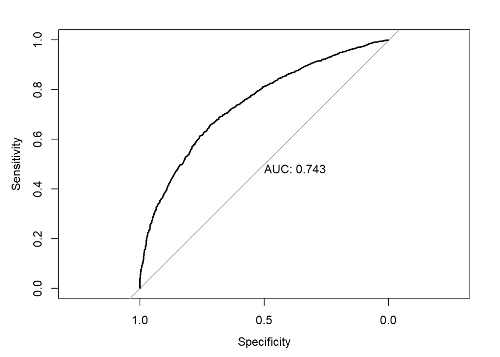

```r
res_fit.lasso.roc <- roc(y_test ~ res_fit.lasso.pred, plot = TRUE,
                         print.auc = TRUE)
```

See the result.

```r
res_fit.lasso.roc.bmetrics <- coords(res_fit.lasso.roc, x="best", ret="all")
res_fit.lasso.roc.bmetrics
```

```
##           threshold specificity sensitivity  accuracy   tn   tp   fn  fp
## threshold 0.7283192   0.7176546    0.657199 0.6726326 1126 3008 1569 443
##                 npv       ppv       fdr       fpr      tpr       tnr      fnr
## threshold 0.4178108 0.8716314 0.1283686 0.2823454 0.657199 0.7176546 0.342801
##           1-specificity 1-sensitivity 1-accuracy     1-npv     1-ppv precision
## threshold     0.2823454      0.342801  0.3273674 0.5821892 0.1283686 0.8716314
##             recall   youden closest.topleft
## threshold 0.657199 1.374854       0.1972314
```

See the confusion matrix using the best threshold value.

```r
table(preds=(res_fit.lasso.pred > res_fit.lasso.roc.bmetrics$threshold), true=as.logical(cl_resp_min_fd.test$fast_response))
```

```
##        true
## preds   FALSE TRUE
##   FALSE  1126 1569
##   TRUE    443 3008
```

Concatenate with the other results.

```r
row.names(res_fit.lasso.roc.bmetrics) <- "Inteaction Full Moldel Lasso"
res_results <- rbind(res_results, res_fit.lasso.roc.bmetrics)
```

## 3.6 Linear Discriminant Analysis

Now we are going to deal with **LDA** or **Linear Discriminant Analysis**. For this type of Generative Model we decide to again use the full model with interaction terms.

LDA assumes that the data is normally distributed which is no our case, however we have decided to estimate its performance in any case.

```r
res_lda.fit <- lda(formula(res_glm.full.inter), data = cl_resp_min_fd.train)
res_lda.fit
```

```
## Call:
## lda(formula(res_glm.full.inter), data = cl_resp_min_fd.train)
##
## Prior probabilities of groups:
##     FALSE      TRUE
## 0.2504882 0.7495118
##
## Group means:
##       inc_boroughBrooklyn inc_boroughManhattan inc_boroughQueens
## FALSE           0.1918142            0.2788696         0.2093552
## TRUE            0.3400641            0.2236335         0.1985562
##       inc_boroughStaten Island cong_dist5 cong_dist6 cong_dist7 cong_dist8
## FALSE               0.03426994 0.06642846 0.05700828 0.06902712 0.06675329
## TRUE                0.05487706 0.08266840 0.04575802 0.10443467 0.11225099
##       cong_dist9 cong_dist10 cong_dist11 cong_dist12 cong_dist13 cong_dist14
## FALSE 0.05018678  0.07731038  0.04628878   0.1370797   0.1299334  0.11206757
## TRUE  0.08212560  0.11355371  0.07463497   0.0810400   0.1091028  0.06513597
##       cong_dist15 cong_dist16 al_source_descEMS al_source_descEMS-911
## FALSE   0.1577067 0.012830924         0.2541822             0.1495858
## TRUE    0.1075286 0.007219237         0.2358465             0.1389567
##       al_source_descOthers al_source_descPHONE al_index_descInitial Alarm
## FALSE           0.01884034           0.4713334                  0.8926425
## TRUE            0.02507735           0.4273463                  0.9026217
##       al_index_descOthers highest_al_levelNonFirst Alarm inc_class_groupM_MFAs
## FALSE        0.0003248335                   0.0001624168           0.004872503
## TRUE         0.0051023178                   0.0045052380           0.004668078
##       inc_class_groupNonM_E inc_class_groupNonM_MFAs inc_class_groupNonS_F
## FALSE             0.5574143               0.02614910           0.007633588
## TRUE              0.5277642               0.03001683           0.020680671
##       inc_class_groupS_F engines_assigned ladders_assigned
## FALSE         0.01413026        0.7791132        0.6114991
## TRUE          0.05932801        1.2714542        0.8376486
##       others_units_assigned day_typeWeekend working_hourTRUE time_of_dayEvening
## FALSE             0.1822316       0.2551567        0.5970440          0.1853175
## TRUE              0.4661022       0.2771536        0.5842697          0.2524019
##       time_of_dayMorning time_of_dayNight tua_is_oneTRUE
## FALSE          0.2975475        0.1758974      0.7566997
## TRUE           0.2637464        0.1362427      0.5178310
##       al_source_descEMS:engines_assigned al_source_descEMS-911:engines_assigned
## FALSE                          0.2512587                              0.1518597
```

[output cut: 62 more lines]

```
## time_of_dayMorning                          -0.083032065
## time_of_dayNight                             0.352142106
## tua_is_oneTRUE                              -1.079275769
## al_source_descEMS:engines_assigned          -0.804415408
## al_source_descEMS-911:engines_assigned      -0.965908967
## al_source_descOthers:engines_assigned        0.645539497
## al_source_descPHONE:engines_assigned         0.475838383
## al_source_descEMS:others_units_assigned     -0.244647493
## al_source_descEMS-911:others_units_assigned -0.316227576
## al_source_descOthers:others_units_assigned  -0.785096861
## al_source_descPHONE:others_units_assigned   -0.342301461
## day_typeWeekend:working_hourTRUE             0.467640805
## time_of_dayEvening:tua_is_oneTRUE           -0.118130856
## time_of_dayMorning:tua_is_oneTRUE           -0.111214460
## time_of_dayNight:tua_is_oneTRUE             -0.558549033
```

The printed output of **lda** includes:

- The a-priori probabilities of fast response
- The group means.

The a-priori probabilities correspond to the sample proportion of fast response of the train dataset.

An example of group mean is the mean fast response time of incidents in the Brooklyn borough.

```r
with(cl_resp_min_fd.train,
     mean(inc_borough[fast_response == TRUE] == "Brooklyn"))
```

```
## [1] 0.3400641
```

Now we make the prediction on the test set.

```r
res_lda.preds <- predict(res_lda.fit,
                         newdata = cl_resp_min_fd.test, type = "response")
```

The ROC curve for linear discriminant analysis is:

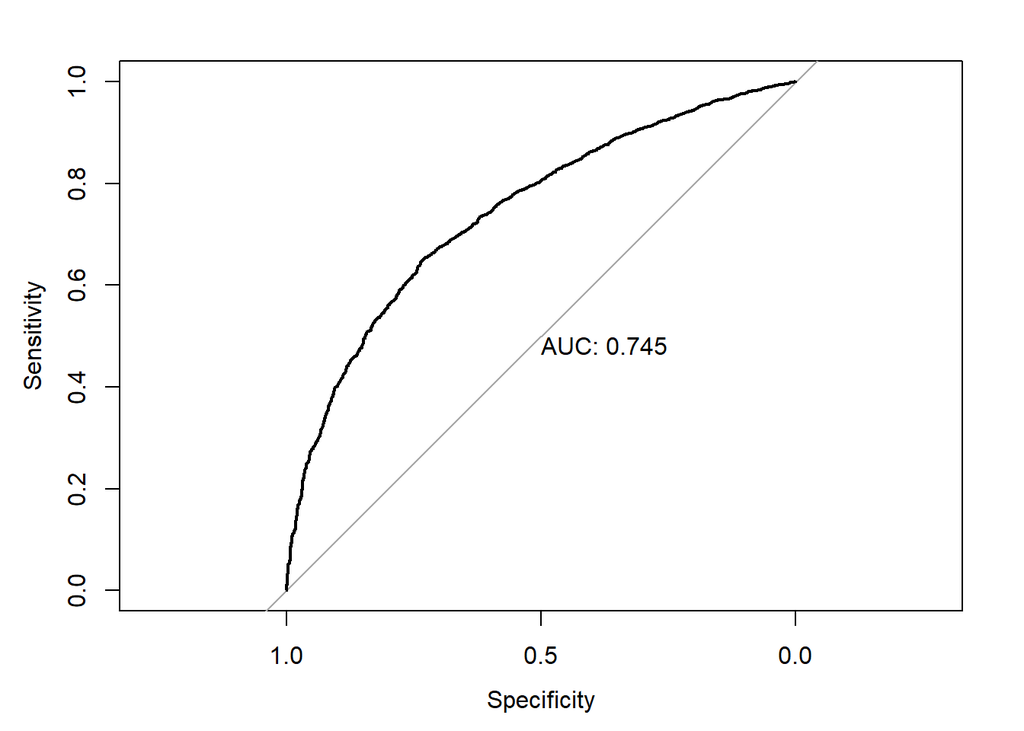

```r
res_lda.roc <- roc(
  cl_resp_min_fd.test$fast_response ~ res_lda.preds$posterior[, 2],
  plot = TRUE, print.auc = TRUE)
```

The best choice for the threshold of linear discriminant analysis yields an accuracy of:

```r
res_lda.roc.bmetrics <- coords(res_lda.roc, x = "best", ret = "all")
res_lda.roc.bmetrics
```

```
##           threshold specificity sensitivity  accuracy   tn   tp   fn  fp
## threshold 0.7622271    0.734863   0.6486782 0.6706801 1153 2969 1608 416
##                 npv       ppv       fdr      fpr       tpr      tnr       fnr
## threshold 0.4176023 0.8771049 0.1228951 0.265137 0.6486782 0.734863 0.3513218
##           1-specificity 1-sensitivity 1-accuracy     1-npv     1-ppv precision
## threshold      0.265137     0.3513218  0.3293199 0.5823977 0.1228951 0.8771049
##              recall   youden closest.topleft
## threshold 0.6486782 1.383541       0.1937247
```

See the confusion matrix using the best threshold value.

```r
table(preds=(res_lda.preds$posterior[, 2] > res_lda.roc.bmetrics$threshold), true=as.logical(cl_resp_min_fd.test$fast_response))
```

```
##        true
## preds   FALSE TRUE
##   FALSE  1153 1608
##   TRUE    416 2969
```

Concatenate with the other results.

```r
row.names(res_lda.roc.bmetrics) <- "Linear Discriminant Analysis"
res_results <- rbind(res_results, res_lda.roc.bmetrics)
```

## 3.7 Naive Baye

Continuing with the analysis we try **Naive Bayes** algorithm. In this case we can’t use a model with interaction term since Naive Bayes do not support these relations. Thus we decide to use the **Full Model**.

Note that Naive Bayes assumes that all predictors are independent to each other.

```r
res_nb.fit <- naiveBayes(formula(res_glm.full), data = cl_resp_min_fd.train)
res_nb.fit
```

```
##
## Naive Bayes Classifier for Discrete Predictors
##
## Call:
## naiveBayes.default(x = X, y = Y, laplace = laplace)
##
## A-priori probabilities:
## Y
##     FALSE      TRUE
## 0.2504882 0.7495118
##
## Conditional probabilities:
##        inc_borough
## Y            Bronx   Brooklyn  Manhattan     Queens Staten Island
##   FALSE 0.28569108 0.19181420 0.27886958 0.20935521    0.03426994
##   TRUE  0.18286924 0.34006405 0.22363350 0.19855615    0.05487706
##
##        cong_dist
## Y                 3           5           6           7           8           9
##   FALSE 0.017378593 0.066428455 0.057008283 0.069027124 0.066753289 0.050186779
##   TRUE  0.014547034 0.082668404 0.045758020 0.104434674 0.112250991 0.082125604
##        cong_dist
## Y                10          11          12          13          14          15
##   FALSE 0.077310378 0.046288777 0.137079747 0.129933409 0.112067565 0.157706675
##   TRUE  0.113553710 0.074634967 0.081040004 0.109102752 0.065135971 0.107528633
##        cong_dist
## Y                16
##   FALSE 0.012830924
##   TRUE  0.007219237
##
##        al_source_desc
## Y          CLASS-3        EMS    EMS-911     Others      PHONE
##   FALSE 0.10605815 0.25418223 0.14958584 0.01884034 0.47133344
##   TRUE  0.17277316 0.23584650 0.13895674 0.02507735 0.42734625
##
##        al_index_desc
## Y       DEFAULT RECORD Initial Alarm       Others
##   FALSE   0.1070326458  0.8926425207 0.0003248335
##   TRUE    0.0922759594  0.9026217228 0.0051023178
##
```

[output cut: 29 more lines]

```
##
##        working_hour
## Y           FALSE      TRUE
##   FALSE 0.4029560 0.5970440
##   TRUE  0.4157303 0.5842697
##
##        time_of_day
## Y       Afternoon   Evening   Morning     Night
##   FALSE 0.3412376 0.1853175 0.2975475 0.1758974
##   TRUE  0.3476090 0.2524019 0.2637464 0.1362427
##
##        tua_is_one
## Y           FALSE      TRUE
##   FALSE 0.2433003 0.7566997
##   TRUE  0.4821690 0.5178310
```

The output of **naiveBayes** contains:

- The estimated a-priori probabilities.
- The estimated conditional probabilities for the qualitative variables.
- The estimated group means and standard deviations for the quantitative variables.

The a-priori probabilities again correspond to the sample proportion of fast response of the train dataset.

An example of conditional probabilities of `al_source_desc` for fast response time are:

```r
with(cl_resp_min_fd.train, table(al_source_desc[fast_response == TRUE]) /
       sum(fast_response == TRUE))
```

```
##
##    CLASS-3        EMS    EMS-911     Others      PHONE
## 0.17277316 0.23584650 0.13895674 0.02507735 0.42734625
```

The mean and standard deviations of `engines_assigned` conditional to the response time speed are:

```r
with(cl_resp_min_fd.train,
     mean(engines_assigned[fast_response == FALSE]))
```

```
## [1] 0.7791132
```

```r
with(cl_resp_min_fd.train,
     sd(engines_assigned[fast_response == FALSE]))
```

```
## [1] 0.7218391
```

```r
with(cl_resp_min_fd.train,
     mean(engines_assigned[fast_response == TRUE]))
```

```
## [1] 1.271454
```

```r
with(cl_resp_min_fd.train,
     sd(engines_assigned[fast_response == TRUE]))
```

```
## [1] 0.9910428
```

Prediction for the test set:

```r
res_nb.preds <- predict(res_nb.fit, newdata = cl_resp_min_fd.test)
table(preds = res_nb.preds, true = cl_resp_min_fd.test$fast_response)
```

```
##        true
## preds   FALSE TRUE
##   FALSE   956 1461
##   TRUE    613 3116
```

Predicted class probabilities can be obtained using the argument **type = “raw”**:

```r
res_nb.posterior <- predict(res_nb.fit,
                            newdata = cl_resp_min_fd.test, type = "raw")
head(res_nb.posterior)
```

```
##             FALSE      TRUE
## [1,] 0.0001211009 0.9998789
## [2,] 0.2581952858 0.7418047
## [3,] 0.8008531809 0.1991468
## [4,] 0.3360633420 0.6639367
## [5,] 0.7692682016 0.2307318
## [6,] 0.4559618379 0.5440382
```

ROC curve:

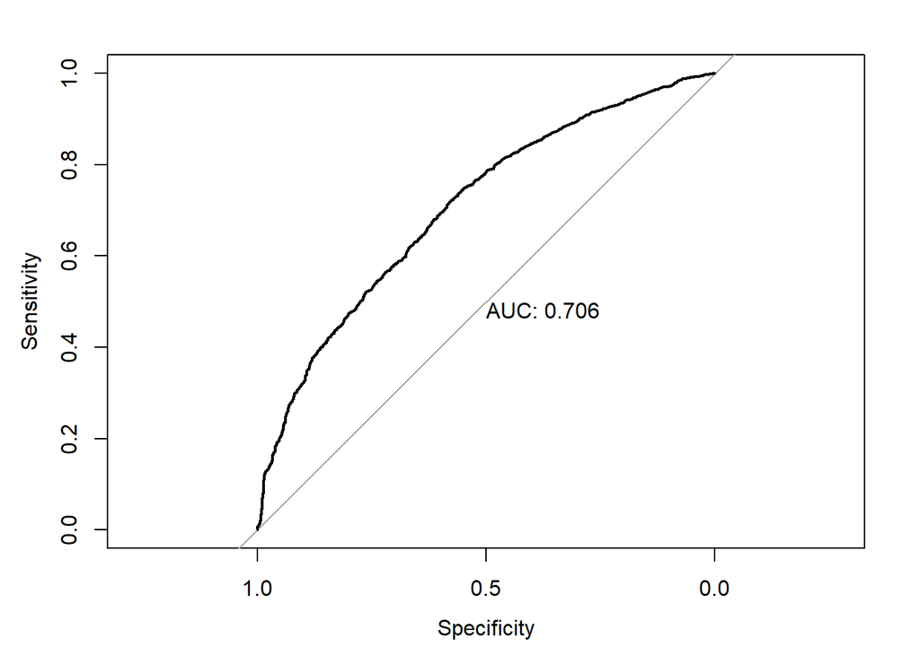

```r
res_nb.roc <- roc(
  cl_resp_min_fd.test$fast_response ~ res_nb.posterior[, 2],
  plot = TRUE, print.auc = TRUE)
```

```r
res_nb.roc.bmetrics <- coords(res_nb.roc, x = "best", ret = "all")
res_nb.roc.bmetrics
```

```
##           threshold specificity sensitivity  accuracy  tn   tp   fn  fp
## threshold 0.4284338   0.5780752   0.7201224 0.6838594 907 3296 1281 662
##                 npv       ppv       fdr       fpr       tpr       tnr       fnr
## threshold 0.4145338 0.8327438 0.1672562 0.4219248 0.7201224 0.5780752 0.2798776
##           1-specificity 1-sensitivity 1-accuracy     1-npv     1-ppv precision
## threshold     0.4219248     0.2798776  0.3161406 0.5854662 0.1672562 0.8327438
##              recall   youden closest.topleft
## threshold 0.7201224 1.298198        0.256352
```

See the confusion matrix using the best threshold value.

```r
table(preds=(res_nb.posterior[, 2] > res_nb.roc.bmetrics$threshold),
      true=as.logical(cl_resp_min_fd.test$fast_response))
```

```
##        true
## preds   FALSE TRUE
##   FALSE   907 1281
##   TRUE    662 3296
```

```r
row.names(res_nb.roc.bmetrics) <- "Naive Bayes"
res_results <- rbind(res_results, res_nb.roc.bmetrics)
```

## 3.8 Conclusion

Finally we make a recap of the final results that we have obtained.

```r
res_results
```

```
##                              threshold specificity sensitivity  accuracy   tn
## Full Model                   0.7357374   0.6806883   0.6849465 0.6838594 1068
## Interaction Full Model       0.7828203   0.7928617   0.5754861 0.6309795 1244
## Cleaned Model                0.7304181   0.6704908   0.6722744 0.6718191 1052
## Interaction Cleaned Model    0.7374082   0.6889739   0.6672493 0.6727953 1081
## Inteaction Full Moldel Ridge 0.7290678   0.7214786   0.6567621 0.6732834 1132
## Inteaction Full Moldel Lasso 0.7283192   0.7176546   0.6571990 0.6726326 1126
## Linear Discriminant Analysis 0.7622271   0.7348630   0.6486782 0.6706801 1153
## Naive Bayes                  0.4284338   0.5780752   0.7201224 0.6838594  907
##                                tp   fn  fp       npv       ppv       fdr
## Full Model                   3135 1442 501 0.4254980 0.8622112 0.1377888
## Interaction Full Model       2634 1943 325 0.3903357 0.8901656 0.1098344
## Cleaned Model                3077 1500 517 0.4122257 0.8561491 0.1438509
## Interaction Cleaned Model    3054 1523 488 0.4151306 0.8622247 0.1377753
## Inteaction Full Moldel Ridge 3006 1571 437 0.4187939 0.8730758 0.1269242
## Inteaction Full Moldel Lasso 3008 1569 443 0.4178108 0.8716314 0.1283686
## Linear Discriminant Analysis 2969 1608 416 0.4176023 0.8771049 0.1228951
## Naive Bayes                  3296 1281 662 0.4145338 0.8327438 0.1672562
##                                    fpr       tpr       tnr       fnr
## Full Model                   0.3193117 0.6849465 0.6806883 0.3150535
## Interaction Full Model       0.2071383 0.5754861 0.7928617 0.4245139
## Cleaned Model                0.3295092 0.6722744 0.6704908 0.3277256
## Interaction Cleaned Model    0.3110261 0.6672493 0.6889739 0.3327507
## Inteaction Full Moldel Ridge 0.2785214 0.6567621 0.7214786 0.3432379
## Inteaction Full Moldel Lasso 0.2823454 0.6571990 0.7176546 0.3428010
## Linear Discriminant Analysis 0.2651370 0.6486782 0.7348630 0.3513218
## Naive Bayes                  0.4219248 0.7201224 0.5780752 0.2798776
##                              1-specificity 1-sensitivity 1-accuracy     1-npv
## Full Model                       0.3193117     0.3150535  0.3161406 0.5745020
## Interaction Full Model           0.2071383     0.4245139  0.3690205 0.6096643
## Cleaned Model                    0.3295092     0.3277256  0.3281809 0.5877743
## Interaction Cleaned Model        0.3110261     0.3327507  0.3272047 0.5848694
## Inteaction Full Moldel Ridge     0.2785214     0.3432379  0.3267166 0.5812061
## Inteaction Full Moldel Lasso     0.2823454     0.3428010  0.3273674 0.5821892
## Linear Discriminant Analysis     0.2651370     0.3513218  0.3293199 0.5823977
## Naive Bayes                      0.4219248     0.2798776  0.3161406 0.5854662
##                                  1-ppv precision    recall   youden
## Full Model                   0.1377888 0.8622112 0.6849465 1.365635
## Interaction Full Model       0.1098344 0.8901656 0.5754861 1.368348
## Cleaned Model                0.1438509 0.8561491 0.6722744 1.342765
## Interaction Cleaned Model    0.1377753 0.8622247 0.6672493 1.356223
## Inteaction Full Moldel Ridge 0.1269242 0.8730758 0.6567621 1.378241
## Inteaction Full Moldel Lasso 0.1283686 0.8716314 0.6571990 1.374854
## Linear Discriminant Analysis 0.1228951 0.8771049 0.6486782 1.383541
## Naive Bayes                  0.1672562 0.8327438 0.7201224 1.298198
##                              closest.topleft
## Full Model                         0.2012187
## Interaction Full Model             0.2231183
## Cleaned Model                      0.2159804
## Interaction Cleaned Model          0.2074603
## Inteaction Full Moldel Ridge       0.1953864
## Inteaction Full Moldel Lasso       0.1972314
## Linear Discriminant Analysis       0.1937247
## Naive Bayes                        0.2563520
```

1. **Specificity**

```r
res_results %>% select(specificity) %>% arrange(desc(specificity))
```

```
##                              specificity
## Interaction Full Model         0.7928617
## Linear Discriminant Analysis   0.7348630
## Inteaction Full Moldel Ridge   0.7214786
## Inteaction Full Moldel Lasso   0.7176546
## Interaction Cleaned Model      0.6889739
## Full Model                     0.6806883
## Cleaned Model                  0.6704908
## Naive Bayes                    0.5780752
```

For the specificity the best model is **Interaction Full Model**.

2. **Sensitivity**

```r
res_results %>% select(sensitivity) %>% arrange(desc(sensitivity))
```

```
##                              sensitivity
## Naive Bayes                    0.7201224
## Full Model                     0.6849465
## Cleaned Model                  0.6722744
## Interaction Cleaned Model      0.6672493
## Inteaction Full Moldel Lasso   0.6571990
## Inteaction Full Moldel Ridge   0.6567621
## Linear Discriminant Analysis   0.6486782
## Interaction Full Model         0.5754861
```

For sensitivity the best model is **Naive Bayes**.

3. **Accuracy**

```r
res_results %>% select(accuracy) %>% arrange(desc(accuracy))
```

```
##                               accuracy
## Full Model                   0.6838594
## Naive Bayes                  0.6838594
## Inteaction Full Moldel Ridge 0.6732834
## Interaction Cleaned Model    0.6727953
## Inteaction Full Moldel Lasso 0.6726326
## Cleaned Model                0.6718191
## Linear Discriminant Analysis 0.6706801
## Interaction Full Model       0.6309795
```

# 4 Use the range of emergency_min_qy as response

Now we will use the second response and perform a similar analysis.

```r
# make a copy of the train and test
cl_emerg_min_fd.train <- fire_data_clean.train
cl_emerg_min_fd.test <- fire_data_clean.test

cl_emerg_min_fd.train$fast_emergency <- cl_emerg_min_fd.train$emergency_min_qy < th_eme
cl_emerg_min_fd.test$fast_emergency <- cl_emerg_min_fd.test$emergency_min_qy < th_eme

# remove the future time differences and units counts
cl_emerg_min_fd.train <- cl_emerg_min_fd.train %>% select(-c(emergency_min_qy))
cl_emerg_min_fd.test <- cl_emerg_min_fd.test %>% select(-c(emergency_min_qy))
```

```r
print(dfSummary(cl_emerg_min_fd.test$fast_emergency,
                plain.ascii  = FALSE,
                style        = "multiline",
                headings     = FALSE,
                graph.magnif = 0.8,
                valid.col    = FALSE,
                na.col       = FALSE),
                method = 'render')
```

```
## cl_emerg_min_fd.test$fast_emergency was converted to a data frame
```

**No**

**Variable**

**Stats / Values**

**Freqs (% of Valid)**

**Graph**

1

fast_emergency [logical]

| 1. FALSE |
| --- |
| 2. TRUE |

| 1530 | ( | 24.9% | ) |
| --- | --- | --- | --- |
| 4616 | ( | 75.1% | ) |

Generated by summarytools 1.0.1 ([R](https://www.r-project.org/) version 4.3.2)  
2024-01-25

```r
print(dfSummary(cl_emerg_min_fd.test$fast_emergency,
                plain.ascii  = FALSE,
                style        = "multiline",
                headings     = FALSE,
                graph.magnif = 0.8,
                valid.col    = FALSE,
                na.col       = FALSE),
                method = 'render')
```

```
## cl_emerg_min_fd.test$fast_emergency was converted to a data frame
```

**No**

**Variable**

**Stats / Values**

**Freqs (% of Valid)**

**Graph**

1

fast_emergency [logical]

| 1. FALSE |
| --- |
| 2. TRUE |

| 1530 | ( | 24.9% | ) |
| --- | --- | --- | --- |
| 4616 | ( | 75.1% | ) |

Generated by summarytools 1.0.1 ([R](https://www.r-project.org/) version 4.3.2)  
2024-01-25

## 4.1 Logistic Regression

Fit our full **Logistic Regression** model.

```r
eme_glm.full <- glm(fast_emergency ~ ., data = cl_emerg_min_fd.train,
                    family = "binomial")
summary(eme_glm.full)
```

```
##
## Call:
## glm(formula = fast_emergency ~ ., family = "binomial", data = cl_emerg_min_fd.train)
##
## Coefficients:
##                                  Estimate Std. Error z value Pr(>|z|)
## (Intercept)                      4.177276   0.268345  15.567  < 2e-16 ***
## inc_boroughBrooklyn              1.035353   0.107306   9.649  < 2e-16 ***
## inc_boroughManhattan             0.110599   0.086770   1.275 0.202445
## inc_boroughQueens                0.562841   0.097884   5.750 8.92e-09 ***
## inc_boroughStaten Island         0.828914   0.188641   4.394 1.11e-05 ***
## cong_dist5                      -0.069822   0.143251  -0.487 0.625967
## cong_dist6                      -0.304174   0.148126  -2.053 0.040026 *
## cong_dist7                      -0.139507   0.153472  -0.909 0.363348
## cong_dist8                      -0.256497   0.172339  -1.488 0.136666
## cong_dist9                       0.110149   0.178800   0.616 0.537863
## cong_dist10                     -0.201332   0.168982  -1.191 0.233483
## cong_dist11                     -0.015489   0.211703  -0.073 0.941674
## cong_dist12                     -0.270695   0.176751  -1.532 0.125645
## cong_dist13                     -0.482186   0.169284  -2.848 0.004394 **
## cong_dist14                     -0.234173   0.157206  -1.490 0.136332
## cong_dist15                     -0.255339   0.168549  -1.515 0.129791
## cong_dist16                      0.022200   0.224720   0.099 0.921306
## al_source_descEMS               -1.107519   0.106290 -10.420  < 2e-16 ***
## al_source_descEMS-911           -1.187242   0.106975 -11.098  < 2e-16 ***
## al_source_descOthers            -1.474092   0.109437 -13.470  < 2e-16 ***
## al_source_descPHONE             -0.688953   0.057894 -11.900  < 2e-16 ***
## al_index_descInitial Alarm      -2.961340   0.148430 -19.951  < 2e-16 ***
## al_index_descOthers            -16.795069 232.422951  -0.072 0.942394
## highest_al_levelNonFirst Alarm  -0.289727 247.708294  -0.001 0.999067
## inc_class_groupM_MFAs            1.685536   1.037126   1.625 0.104120
## inc_class_groupNonM_E            0.655104   0.096325   6.801 1.04e-11 ***
## inc_class_groupNonM_MFAs         1.296262   0.446142   2.905 0.003667 **
## inc_class_groupNonS_F           -0.377544   0.140058  -2.696 0.007026 **
## inc_class_groupS_F               0.428711   0.125456   3.417 0.000633 ***
## inc_resp_min_qy                 -0.025202   0.006052  -4.165 3.12e-05 ***
## engines_assigned                -0.155327   0.027233  -5.704 1.17e-08 ***
## ladders_assigned                 0.010348   0.043755   0.237 0.813045
## others_units_assigned           -0.167047   0.027942  -5.978 2.25e-09 ***
## day_typeWeekend                  0.035967   0.035804   1.005 0.315113
## working_hourTRUE                 0.042685   0.091941   0.464 0.642454
## time_of_dayEvening               0.400036   0.101722   3.933 8.40e-05 ***
## time_of_dayMorning              -0.120741   0.040866  -2.955 0.003131 **
## time_of_dayNight                 0.365239   0.105068   3.476 0.000509 ***
## tua_is_oneTRUE                   0.342123   0.062649   5.461 4.74e-08 ***
## ---
## Signif. codes:  0 '***' 0.001 '**' 0.01 '*' 0.05 '.' 0.1 ' ' 1
##
## (Dispersion parameter for binomial family taken to be 1)
##
##     Null deviance: 27673  on 24579  degrees of freedom
## Residual deviance: 24118  on 24541  degrees of freedom
## AIC: 24196
##
## Number of Fisher Scoring iterations: 13
```

Let’s check if we have some **multicollinearity** problem using the `vif` function as we did on the previous analysis part.

```r
vif(eme_glm.full)
```

```
##                             GVIF Df GVIF^(1/(2*Df))
## inc_borough           320.257624  4        2.056778
## cong_dist             331.518055 12        1.273565
## al_source_desc         11.320891  4        1.354363
## al_index_desc           9.778296  2        1.768340
## highest_al_level        8.360694  1        2.891487
## inc_class_group        12.546127  5        1.287808
## inc_resp_min_qy         1.137345  1        1.066464
## engines_assigned        2.439042  1        1.561743
## ladders_assigned        4.998764  1        2.235792
## others_units_assigned   1.691384  1        1.300532
## day_type                1.005962  1        1.002977
## working_hour            7.951905  1        2.819912
## time_of_day             8.104888  3        1.417287
## tua_is_one              3.808189  1        1.951458
```

Now we remove the non significant predictor building as before the cleaned model.

```r
eme_glm.clean <- update(eme_glm.full, . ~ . - cong_dist - highest_al_level -
                          inc_class_group - day_type - working_hour,
                        data = cl_emerg_min_fd.train)
vif(eme_glm.clean)
```

```
##                           GVIF Df GVIF^(1/(2*Df))
## inc_borough           1.086254  4        1.010396
## al_source_desc        3.945434  4        1.187167
## al_index_desc         1.012356  2        1.003075
## inc_resp_min_qy       1.119533  1        1.058080
## engines_assigned      2.147145  1        1.465314
## ladders_assigned      4.514392  1        2.124710
## others_units_assigned 1.678472  1        1.295558
## time_of_day           1.021139  3        1.003493
## tua_is_one            3.610041  1        1.900011
```

Let’s see the summary of the updated cleaned model.

```r
summary(eme_glm.clean)
```

```
##
## Call:
## glm(formula = fast_emergency ~ inc_borough + al_source_desc +
##     al_index_desc + inc_resp_min_qy + engines_assigned + ladders_assigned +
##     others_units_assigned + time_of_day + tua_is_one, family = "binomial",
##     data = cl_emerg_min_fd.train)
##
## Coefficients:
##                              Estimate Std. Error z value Pr(>|z|)
## (Intercept)                  4.727588   0.163815  28.859  < 2e-16 ***
## inc_boroughBrooklyn          1.161389   0.046407  25.026  < 2e-16 ***
## inc_boroughManhattan         0.035830   0.043526   0.823 0.410398
## inc_boroughQueens            0.668683   0.047439  14.096  < 2e-16 ***
## inc_boroughStaten Island     1.071448   0.083045  12.902  < 2e-16 ***
## al_source_descEMS           -1.538306   0.075460 -20.386  < 2e-16 ***
## al_source_descEMS-911       -1.604379   0.078549 -20.425  < 2e-16 ***
## al_source_descOthers        -1.550998   0.107404 -14.441  < 2e-16 ***
## al_source_descPHONE         -0.744873   0.056606 -13.159  < 2e-16 ***
## al_index_descInitial Alarm  -3.110025   0.137801 -22.569  < 2e-16 ***
## al_index_descOthers        -17.412916  80.604584  -0.216 0.828965
## inc_resp_min_qy             -0.021363   0.005997  -3.562 0.000368 ***
## engines_assigned            -0.244109   0.025362  -9.625  < 2e-16 ***
## ladders_assigned             0.122211   0.041470   2.947 0.003209 **
## others_units_assigned       -0.155663   0.027631  -5.634 1.76e-08 ***
## time_of_dayEvening           0.351796   0.043235   8.137 4.06e-16 ***
## time_of_dayMorning          -0.119190   0.039289  -3.034 0.002416 **
## time_of_dayNight             0.312579   0.050552   6.183 6.28e-10 ***
## tua_is_oneTRUE               0.247335   0.060736   4.072 4.66e-05 ***
## ---
## Signif. codes:  0 '***' 0.001 '**' 0.01 '*' 0.05 '.' 0.1 ' ' 1
##
## (Dispersion parameter for binomial family taken to be 1)
##
##     Null deviance: 27673  on 24579  degrees of freedom
## Residual deviance: 24308  on 24561  degrees of freedom
## AIC: 24346
##
## Number of Fisher Scoring iterations: 13
```

Compare the **AIC** for the two models.

```r
AIC(eme_glm.full, eme_glm.clean) %>% arrange(AIC)
```

```
##               df      AIC
## eme_glm.full  39 24196.12
## eme_glm.clean 19 24346.15
```

The cleaned model appears to have a higher AIC thus up to now we prefer the full initial model.

Now we decide to update the previous model by adding an interaction term for each type of assigned units with the alarm source description.

```r
eme_glm.clean.inter <- update(eme_glm.clean, . ~ . +
                                al_source_desc : engines_assigned +
                                al_source_desc : others_units_assigned +
                                al_source_desc : ladders_assigned,
                              data = cl_emerg_min_fd.train)
summary(eme_glm.clean.inter)
```

```
##
## Call:
## glm(formula = fast_emergency ~ inc_borough + al_source_desc +
##     al_index_desc + inc_resp_min_qy + engines_assigned + ladders_assigned +
##     others_units_assigned + time_of_day + tua_is_one + al_source_desc:engines_assigned +
##     al_source_desc:others_units_assigned + al_source_desc:ladders_assigned,
##     family = "binomial", data = cl_emerg_min_fd.train)
##
## Coefficients:
##                                               Estimate Std. Error z value
## (Intercept)                                   4.866216   0.188200  25.857
## inc_boroughBrooklyn                           1.171604   0.046555  25.166
## inc_boroughManhattan                          0.038907   0.043719   0.890
## inc_boroughQueens                             0.670444   0.047572  14.093
## inc_boroughStaten Island                      1.074110   0.083272  12.899
## al_source_descEMS                            -1.547620   0.198594  -7.793
## al_source_descEMS-911                        -1.220875   0.225699  -5.409
## al_source_descOthers                         -1.501677   0.213802  -7.024
## al_source_descPHONE                          -0.933234   0.137663  -6.779
## al_index_descInitial Alarm                   -3.118503   0.137947 -22.607
## al_index_descOthers                         -17.120835  78.602600  -0.218
## inc_resp_min_qy                              -0.020892   0.006088  -3.432
## engines_assigned                             -0.110727   0.076133  -1.454
## ladders_assigned                             -0.071152   0.121376  -0.586
## others_units_assigned                        -0.294441   0.092474  -3.184
## time_of_dayEvening                            0.353083   0.043302   8.154
## time_of_dayMorning                           -0.118255   0.039368  -3.004
## time_of_dayNight                              0.315193   0.050653   6.223
## tua_is_oneTRUE                                0.303390   0.068486   4.430
## al_source_descEMS:engines_assigned           -0.336026   0.173573  -1.936
## al_source_descEMS-911:engines_assigned       -0.745834   0.203697  -3.661
## al_source_descOthers:engines_assigned        -0.649554   0.174122  -3.730
## al_source_descPHONE:engines_assigned         -0.067304   0.082823  -0.813
## al_source_descEMS:others_units_assigned       0.370379   0.123337   3.003
## al_source_descEMS-911:others_units_assigned   0.232690   0.140903   1.651
## al_source_descOthers:others_units_assigned    0.130313   0.118862   1.096
## al_source_descPHONE:others_units_assigned     0.066615   0.099447   0.670
## al_source_descEMS:ladders_assigned            0.155153   0.217092   0.715
## al_source_descEMS-911:ladders_assigned        0.550939   0.205673   2.679
## al_source_descOthers:ladders_assigned         0.545892   0.209677   2.603
```

[output cut: 28 more lines]

```
## al_source_descPHONE:others_units_assigned   0.502948
## al_source_descEMS:ladders_assigned          0.474801
## al_source_descEMS-911:ladders_assigned      0.007391 **
## al_source_descOthers:ladders_assigned       0.009228 **
## al_source_descPHONE:ladders_assigned        0.168993
## ---
## Signif. codes:  0 '***' 0.001 '**' 0.01 '*' 0.05 '.' 0.1 ' ' 1
##
## (Dispersion parameter for binomial family taken to be 1)
##
##     Null deviance: 27673  on 24579  degrees of freedom
## Residual deviance: 24256  on 24549  degrees of freedom
## AIC: 24318
##
## Number of Fisher Scoring iterations: 13
```

```r
AIC(eme_glm.full, eme_glm.clean, eme_glm.clean.inter) %>% arrange(AIC)
```

```
##                     df      AIC
## eme_glm.full        39 24196.12
## eme_glm.clean.inter 31 24317.68
## eme_glm.clean       19 24346.15
```

By looking at the AIC the best model remain the initial full model.

Now to have a complete comparison we decided to add the same interaction terms to the initial full model.

```r
eme_glm.full.inter <- update(eme_glm.full, . ~ . +
                               al_source_desc : engines_assigned +
                               al_source_desc : others_units_assigned +
                               al_source_desc : ladders_assigned,
                             data = cl_emerg_min_fd.train)
summary(eme_glm.full.inter)
```

```
##
## Call:
## glm(formula = fast_emergency ~ inc_borough + cong_dist + al_source_desc +
##     al_index_desc + highest_al_level + inc_class_group + inc_resp_min_qy +
##     engines_assigned + ladders_assigned + others_units_assigned +
##     day_type + working_hour + time_of_day + tua_is_one + al_source_desc:engines_assigned +
##     al_source_desc:others_units_assigned + al_source_desc:ladders_assigned,
##     family = "binomial", data = cl_emerg_min_fd.train)
##
## Coefficients:
##                                               Estimate Std. Error z value
## (Intercept)                                   4.237871   0.290035  14.612
## inc_boroughBrooklyn                           1.046693   0.107628   9.725
## inc_boroughManhattan                          0.104808   0.087014   1.205
## inc_boroughQueens                             0.584026   0.098252   5.944
## inc_boroughStaten Island                      0.823282   0.189196   4.351
## cong_dist5                                   -0.083960   0.143784  -0.584
## cong_dist6                                   -0.301180   0.148665  -2.026
## cong_dist7                                   -0.128928   0.154025  -0.837
## cong_dist8                                   -0.236526   0.172917  -1.368
## cong_dist9                                    0.123403   0.179299   0.688
## cong_dist10                                  -0.185688   0.169553  -1.095
## cong_dist11                                   0.008240   0.212332   0.039
## cong_dist12                                  -0.245130   0.177360  -1.382
## cong_dist13                                  -0.451407   0.169883  -2.657
## cong_dist14                                  -0.225463   0.157786  -1.429
## cong_dist15                                  -0.237572   0.169130  -1.405
## cong_dist16                                   0.039050   0.225244   0.173
## al_source_descEMS                            -1.019148   0.221439  -4.602
## al_source_descEMS-911                        -0.677527   0.247834  -2.734
## al_source_descOthers                         -1.372197   0.220914  -6.211
## al_source_descPHONE                          -0.886789   0.141391  -6.272
## al_index_descInitial Alarm                   -2.965295   0.148509 -19.967
## al_index_descOthers                         -16.202313 224.023227  -0.072
## highest_al_levelNonFirst Alarm               -0.626925 239.294020  -0.003
## inc_class_groupM_MFAs                         1.699263   1.065193   1.595
## inc_class_groupNonM_E                         0.705537   0.108686   6.492
## inc_class_groupNonM_MFAs                      1.347240   0.449490   2.997
## inc_class_groupNonS_F                        -0.353980   0.151222  -2.341
## inc_class_groupS_F                            0.423502   0.135445   3.127
```

[output cut: 69 more lines]

```
## al_source_descPHONE:others_units_assigned   0.339205
## al_source_descEMS:ladders_assigned          0.259655
## al_source_descEMS-911:ladders_assigned      0.388797
## al_source_descOthers:ladders_assigned       0.093600 .
## al_source_descPHONE:ladders_assigned        0.629937
## ---
## Signif. codes:  0 '***' 0.001 '**' 0.01 '*' 0.05 '.' 0.1 ' ' 1
##
## (Dispersion parameter for binomial family taken to be 1)
##
##     Null deviance: 27673  on 24579  degrees of freedom
## Residual deviance: 24065  on 24529  degrees of freedom
## AIC: 24167
##
## Number of Fisher Scoring iterations: 13
```

```r
AIC(eme_glm.full, eme_glm.full.inter, eme_glm.clean, eme_glm.clean.inter) %>% arrange(AIC)
```

```
##                     df      AIC
## eme_glm.full.inter  51 24167.10
## eme_glm.full        39 24196.12
## eme_glm.clean.inter 31 24317.68
## eme_glm.clean       19 24346.15
```

And it seems like that the full model with the interaction is just slightly better with respect to the full model without interaction terms.

## 4.2 Model Interpretation

We decide to interpret the model with the lower AIC, so the **eme_glm.full.inter** which has $24167.10$ as AIC.

For interpreting the specified model we decide to use the library `effect`. Let’s recall the summary of the model, and see the effects of some strongly significant predictors.

```r
summary(eme_glm.full.inter)
```

```
##
## Call:
## glm(formula = fast_emergency ~ inc_borough + cong_dist + al_source_desc +
##     al_index_desc + highest_al_level + inc_class_group + inc_resp_min_qy +
##     engines_assigned + ladders_assigned + others_units_assigned +
##     day_type + working_hour + time_of_day + tua_is_one + al_source_desc:engines_assigned +
##     al_source_desc:others_units_assigned + al_source_desc:ladders_assigned,
##     family = "binomial", data = cl_emerg_min_fd.train)
##
## Coefficients:
##                                               Estimate Std. Error z value
## (Intercept)                                   4.237871   0.290035  14.612
## inc_boroughBrooklyn                           1.046693   0.107628   9.725
## inc_boroughManhattan                          0.104808   0.087014   1.205
## inc_boroughQueens                             0.584026   0.098252   5.944
## inc_boroughStaten Island                      0.823282   0.189196   4.351
## cong_dist5                                   -0.083960   0.143784  -0.584
## cong_dist6                                   -0.301180   0.148665  -2.026
## cong_dist7                                   -0.128928   0.154025  -0.837
## cong_dist8                                   -0.236526   0.172917  -1.368
## cong_dist9                                    0.123403   0.179299   0.688
## cong_dist10                                  -0.185688   0.169553  -1.095
## cong_dist11                                   0.008240   0.212332   0.039
## cong_dist12                                  -0.245130   0.177360  -1.382
## cong_dist13                                  -0.451407   0.169883  -2.657
## cong_dist14                                  -0.225463   0.157786  -1.429
## cong_dist15                                  -0.237572   0.169130  -1.405
## cong_dist16                                   0.039050   0.225244   0.173
## al_source_descEMS                            -1.019148   0.221439  -4.602
## al_source_descEMS-911                        -0.677527   0.247834  -2.734
## al_source_descOthers                         -1.372197   0.220914  -6.211
## al_source_descPHONE                          -0.886789   0.141391  -6.272
## al_index_descInitial Alarm                   -2.965295   0.148509 -19.967
## al_index_descOthers                         -16.202313 224.023227  -0.072
## highest_al_levelNonFirst Alarm               -0.626925 239.294020  -0.003
## inc_class_groupM_MFAs                         1.699263   1.065193   1.595
## inc_class_groupNonM_E                         0.705537   0.108686   6.492
## inc_class_groupNonM_MFAs                      1.347240   0.449490   2.997
## inc_class_groupNonS_F                        -0.353980   0.151222  -2.341
## inc_class_groupS_F                            0.423502   0.135445   3.127
```

[output cut: 69 more lines]

```
## al_source_descPHONE:others_units_assigned   0.339205
## al_source_descEMS:ladders_assigned          0.259655
## al_source_descEMS-911:ladders_assigned      0.388797
## al_source_descOthers:ladders_assigned       0.093600 .
## al_source_descPHONE:ladders_assigned        0.629937
## ---
## Signif. codes:  0 '***' 0.001 '**' 0.01 '*' 0.05 '.' 0.1 ' ' 1
##
## (Dispersion parameter for binomial family taken to be 1)
##
##     Null deviance: 27673  on 24579  degrees of freedom
## Residual deviance: 24065  on 24529  degrees of freedom
## AIC: 24167
##
## Number of Fisher Scoring iterations: 13
```

We analyse the effects of the following predictors: `inc_borough`, `inc_class_group`, `al_source_desc`, and `inc_resp_min_qy`.

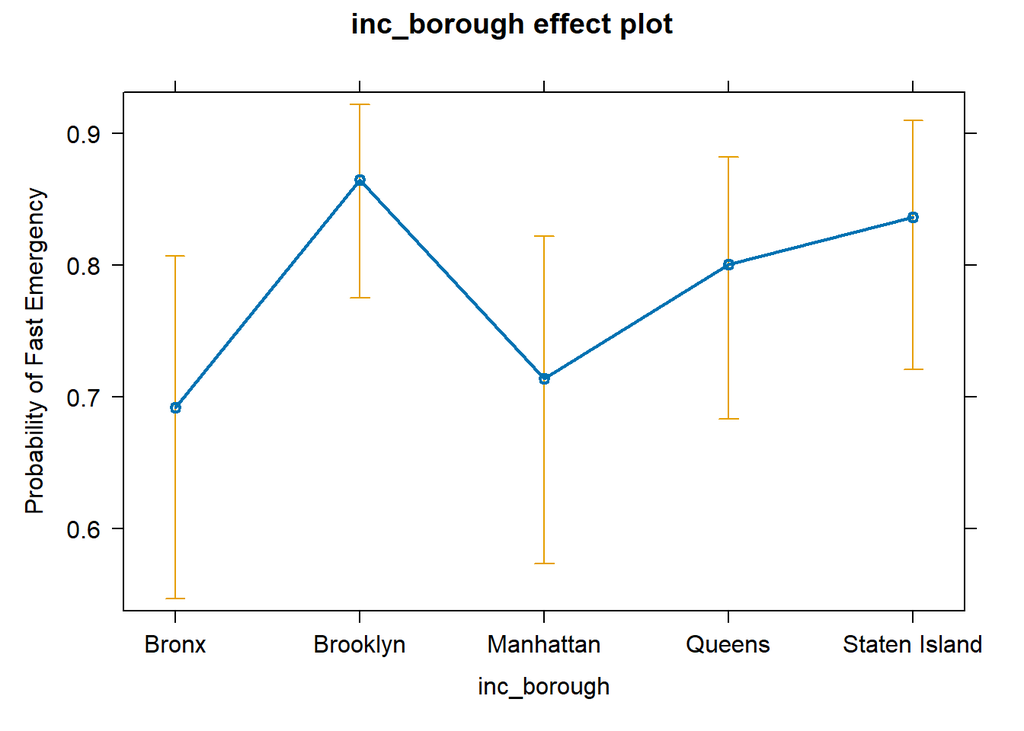

```r
plot(effect("inc_borough", eme_glm.full.inter), rescale.axis = FALSE,
     ylab = "Probability of Fast Emergency")
```

The higher probability of having a fast emergency is for the borough of **Brooklyn**, whereas the lower probability is for both **Bronx** and **Manhattan** having also a pretty big confidence interval.

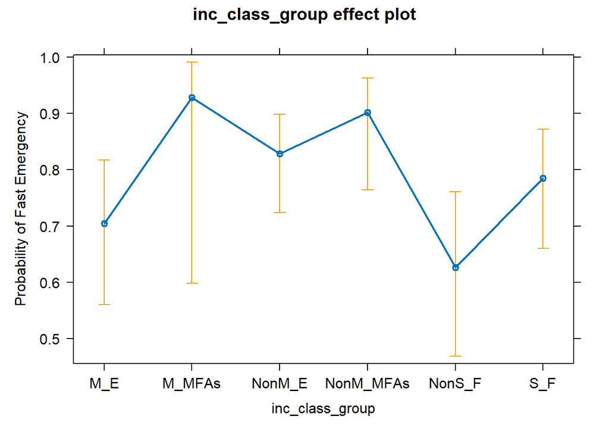

```r
plot(effect("inc_class_group", eme_glm.full.inter), rescale.axis = FALSE,
     ylab = "Probability of Fast Emergency")
```

As expected we have a lower probability to have a fast emergency for the and **NonFire Emergencies** and **Medical Emergencies**. On the other hand we have a higher probability of having a fast emergency for the **Medical MFAs** even if there is a big confidence interval.

```
## NOTE: al_source_desc is not a high-order term in the model
```

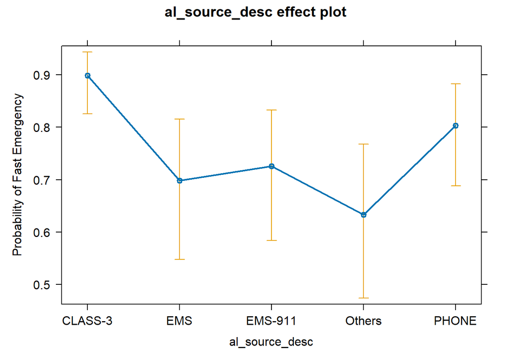

```r
plot(effect("al_source_desc", eme_glm.full.inter), rescale.axis = FALSE,
     ylab = "Probability of Fast Emergency")
```

We have the highest probability of having a fast emergency for the category **CLASS-3** with small confidence interval, whereas the lowest is from the **Others**.

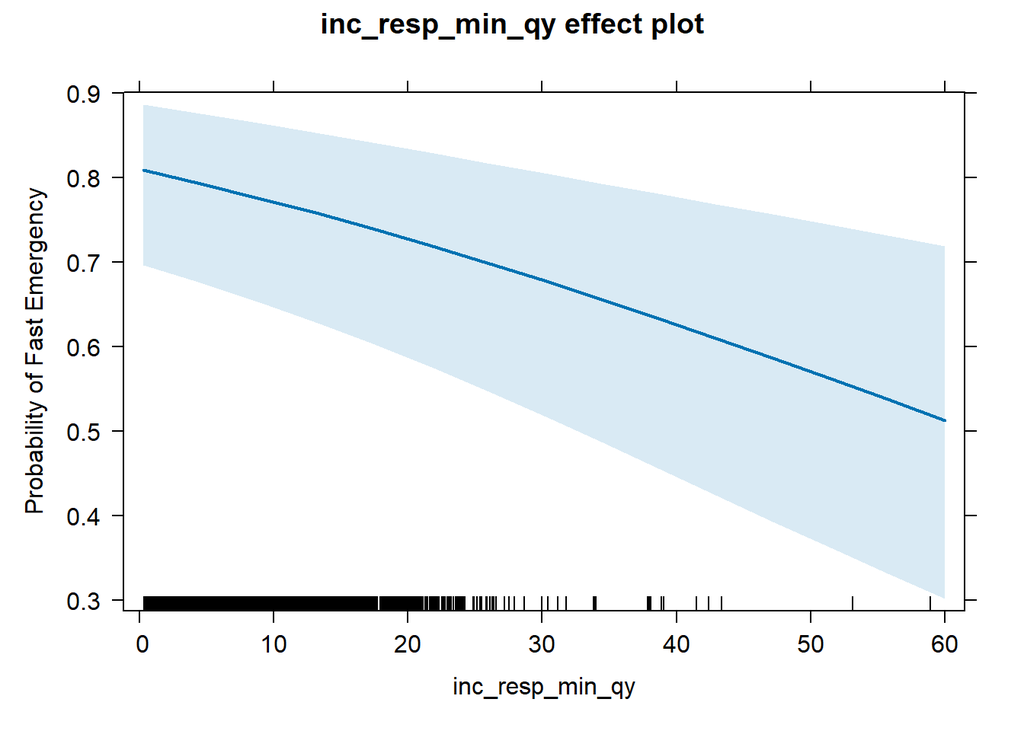

```r
plot(effect("inc_resp_min_qy", eme_glm.full.inter), rescale.axis = FALSE,
     ylab = "Probability of Fast Emergency")
```

As expected having a quick response time is much likely to have higher probability of fast emergency, whereas slow response means low probability of having a fast emergency.

## 4.3 Model Comparison

Now we see if what the *AIC* suggest to us is correct in practice or not by doing predictions on the test dataset.

```r
eme_glm.full.pred <- predict(eme_glm.full, newdata = cl_emerg_min_fd.test,
                             type = "response")

eme_glm.full.inter.pred <- predict(eme_glm.full.inter, newdata = cl_emerg_min_fd.test,
                             type = "response")

eme_glm.clean.pred <- predict(eme_glm.clean, newdata = cl_emerg_min_fd.test,
                              type = "response")

eme_glm.clean.inter.pred <- predict(eme_glm.clean.inter, newdata = cl_emerg_min_fd.test,
                              type = "response")
```

At this point we use the `pROC` library in order to extrapolate the best threshold using the function `roc`.

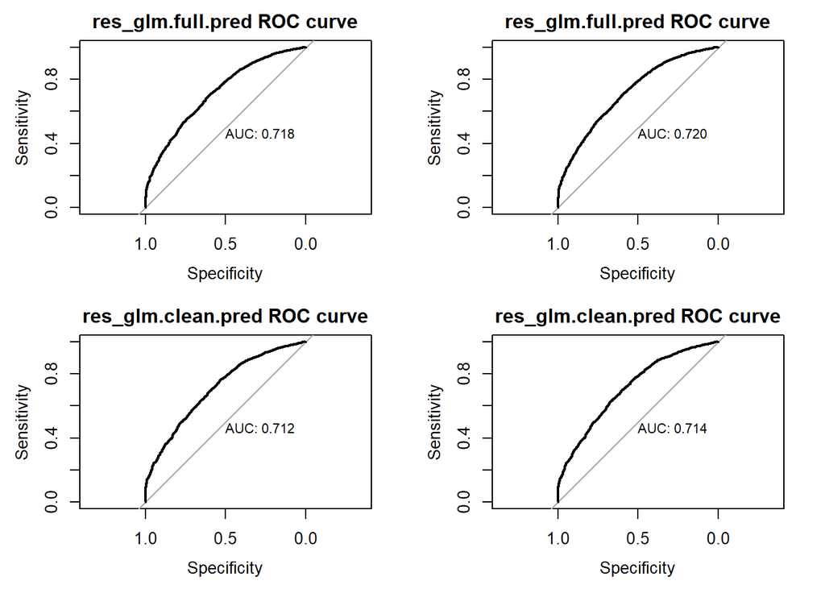

```r
par(mfrow=c(2,2))

eme_glm.full.roc <- roc(
  cl_emerg_min_fd.test$fast_emergency ~ eme_glm.full.pred, plot = TRUE,
  print.auc = TRUE, main = "res_glm.full.pred ROC curve")
eme_glm.full.inter.roc <- roc(
  cl_emerg_min_fd.test$fast_emergency ~ eme_glm.full.inter.pred, plot = TRUE,
  print.auc = TRUE, main = "res_glm.full.pred ROC curve")
eme_glm.clean.roc <- roc(
  cl_emerg_min_fd.test$fast_emergency ~ eme_glm.clean.pred, plot = TRUE,
  print.auc = TRUE, main = "res_glm.clean.pred ROC curve")
eme_glm.clean.inter.roc <- roc(
  cl_emerg_min_fd.test$fast_emergency ~ eme_glm.clean.inter.pred, plot = TRUE,
  print.auc = TRUE, main = "res_glm.clean.pred ROC curve")
```

By the plots we can see that the Area Under the Curve (AUC) computed by the ROC curves gives almost the same results.

Now we extract from each `roc` object the best threshold in order to use it during predictions.

```r
eme_glm.full.roc.bmetrics <- coords(eme_glm.full.roc, x = "best", ret = "all")

eme_glm.full.inter.roc.bmetrics <- coords(eme_glm.full.inter.roc, x = "best", ret = "all")

eme_glm.clean.roc.bmetrics <- coords(eme_glm.clean.roc, x = "best", ret = "all")

eme_glm.clean.inter.roc.bmetrics <- coords(eme_glm.clean.inter.roc, x = "best", ret = "all")
```

Rename the single row for each dataframe and concatenate all in a single one.

```r
row.names(eme_glm.full.roc.bmetrics) <- "Full Model"
row.names(eme_glm.full.inter.roc.bmetrics) <- "Interaction Full Model"
row.names(eme_glm.clean.roc.bmetrics) <- "Cleaned Model"
row.names(eme_glm.clean.inter.roc.bmetrics) <- "Interaction Cleaned Model"

eme_results <- rbind(eme_glm.full.roc.bmetrics, eme_glm.full.inter.roc.bmetrics, eme_glm.clean.roc.bmetrics, eme_glm.clean.inter.roc.bmetrics)
```

Now we make a comparisons result:

1. **Specificity**

```r
eme_results %>% select(specificity) %>% arrange(desc(specificity))
```

```
##                           specificity
## Interaction Cleaned Model   0.6758170
## Full Model                  0.6130719
## Interaction Full Model      0.5921569
## Cleaned Model               0.5326797
```

2. **Sensitivity**

```r
eme_results %>% select(sensitivity) %>% arrange(desc(sensitivity))
```

```
##                           sensitivity
## Cleaned Model               0.7642981
## Interaction Full Model      0.7133882
## Full Model                  0.6934575
## Interaction Cleaned Model   0.6256499
```

Regarding the sensitivity the best model is the **Cleaned Model**.

3. **Accuracy**

```r
eme_results %>% select(accuracy) %>% arrange(desc(accuracy))
```

```
##                            accuracy
## Cleaned Model             0.7066385
## Interaction Full Model    0.6832086
## Full Model                0.6734461
## Interaction Cleaned Model 0.6381386
```

And finally for the accuracy measure the best model is the **Cleaned Model**.

However as initially saw we have an unbalanced problem, so for the same reasons of the previous analysis we decide to opt for the **Cleaned Model**.

Let’s have a quick look on the confusion matrix for the four model that we have specified.

1- **Full Model**

```r
table(preds=(eme_glm.full.pred > eme_glm.full.roc.bmetrics$threshold),
      true=as.logical(cl_emerg_min_fd.test$fast_emergency))
```

```
##        true
## preds   FALSE TRUE
##   FALSE   938 1415
##   TRUE    592 3201
```

2. **Interaction Full Model**

```r
table(preds=(eme_glm.full.inter.pred > eme_glm.full.inter.roc.bmetrics$threshold),
      true=as.logical(cl_emerg_min_fd.test$fast_emergency))
```

```
##        true
## preds   FALSE TRUE
##   FALSE   906 1323
##   TRUE    624 3293
```

3- **Cleaned Model**

```r
table(preds=(eme_glm.clean.pred > eme_glm.clean.roc.bmetrics$threshold),
      true=as.logical(cl_emerg_min_fd.test$fast_emergency))
```

```
##        true
## preds   FALSE TRUE
##   FALSE   815 1088
##   TRUE    715 3528
```

4- **Interaction Cleaned Model**

```r
table(preds=(eme_glm.clean.inter.pred > eme_glm.clean.inter.roc.bmetrics$threshold),
      true=as.logical(cl_emerg_min_fd.test$fast_emergency))
```

```
##        true
## preds   FALSE TRUE
##   FALSE  1034 1728
##   TRUE    496 2888
```

Now we decide to Shrinkage the latter model by running **Ridge Regression** and **Lasso Regression**.

## 4.4 Ridge Shrinkage Estimation

We decide to use the interaction full model in order to see how ridge is able to shrinkage the coefficients.

First of all we have to create our model matrices.

```r
# model matrix for train
x_train <- model.matrix(formula(eme_glm.full.inter), data = cl_emerg_min_fd.train)
y_train <- cl_emerg_min_fd.train$fast_emergency

# mode matrix for test
x_test <- model.matrix(formula(eme_glm.full.inter), data = cl_emerg_min_fd.test)
y_test <- cl_emerg_min_fd.test$fast_emergency
```

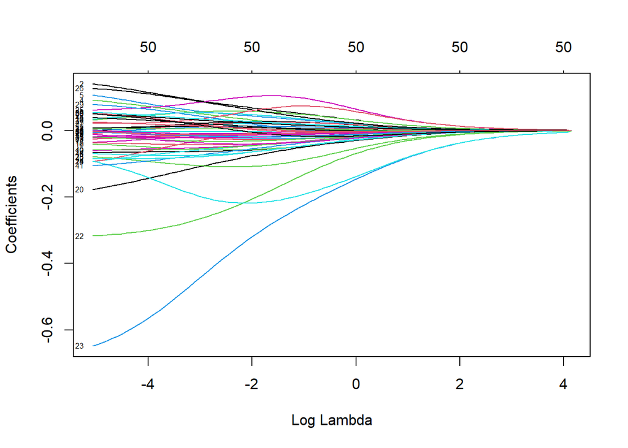

```r
eme_fit.ridge <- glmnet(x_train, y_train, familiy = "binomial", alpha = 0)
plot(eme_fit.ridge, xvar = "lambda", label = TRUE)
```

Choose the best value of lambda via cross-validation.

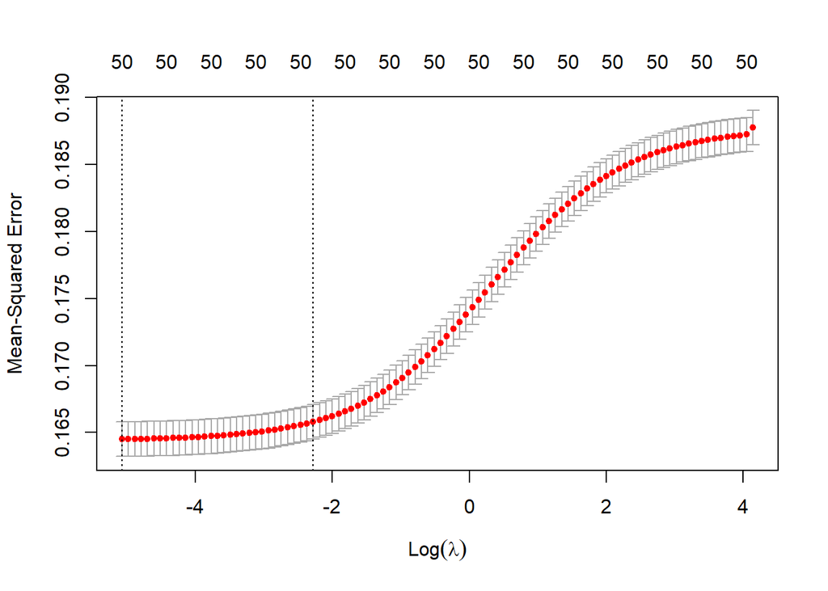

```r
eme_cv.ridge <- cv.glmnet(x_train, y_train, familiy = "binomial", alpha = 0)
plot(eme_cv.ridge)
```

The value of $\lambda$ that minimizes the ridge cross-validated mean square error is:

```r
eme_cv.ridge$lambda.min
```

```
## [1] 0.006282884
```

However, empirical experience suggests to select the simplest model whose $\lambda$ value is within one standard error from the minimum of the cross-validated mean square error:

```r
eme_bestlam.ridge <- eme_cv.ridge$lambda.1se
eme_bestlam.ridge
```

```
## [1] 0.1023953
```

Now visualize again the ridge estimates as a function of the logarithm of $\lambda$ and add a vertical line corresponding to **best.lambda**:

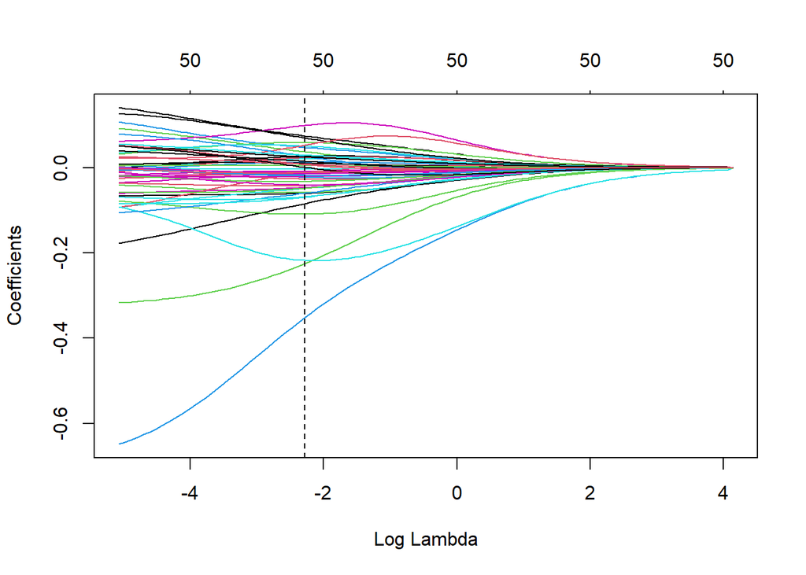

```r
plot(eme_fit.ridge, xvar = "lambda")
abline(v = log(eme_bestlam.ridge), lwd = 1.2, lty = "dashed")
```

These are the coefficients:

```r
coef(eme_fit.ridge,  s=eme_bestlam.ridge)
```

```
## 52 x 1 sparse Matrix of class "dgCMatrix"
##                                                        s1
## (Intercept)                                  0.9899920162
## (Intercept)                                  .
## inc_boroughBrooklyn                          0.0742994612
## inc_boroughManhattan                        -0.0267611647
## inc_boroughQueens                            0.0372299531
## inc_boroughStaten Island                     0.0475408658
## cong_dist5                                   0.0209321112
## cong_dist6                                  -0.0104931141
## cong_dist7                                   0.0261312317
## cong_dist8                                   0.0231717634
## cong_dist9                                   0.0585092007
## cong_dist10                                  0.0127474369
## cong_dist11                                  0.0505636203
## cong_dist12                                 -0.0086185978
## cong_dist13                                 -0.0602360847
## cong_dist14                                 -0.0417935550
## cong_dist15                                 -0.0582245820
## cong_dist16                                 -0.0223170048
## al_source_descEMS                           -0.0486428400
## al_source_descEMS-911                       -0.0466762684
## al_source_descOthers                        -0.0841262519
## al_source_descPHONE                         -0.0122921335
## al_index_descInitial Alarm                  -0.2246231161
## al_index_descOthers                         -0.3513228504
## highest_al_levelNonFirst Alarm              -0.2174613777
## inc_class_groupM_MFAs                        0.0991596449
## inc_class_groupNonM_E                        0.0697512287
## inc_class_groupNonM_MFAs                     0.0528517634
## inc_class_groupNonS_F                       -0.1091723156
## inc_class_groupS_F                           0.0267866229
## inc_resp_min_qy                             -0.0030032062
## engines_assigned                            -0.0143104066
## ladders_assigned                             0.0100887200
## others_units_assigned                       -0.0117609872
## day_typeWeekend                              0.0045340086
## working_hourTRUE                            -0.0194119064
## time_of_dayEvening                           0.0290415691
## time_of_dayMorning                          -0.0208797115
## time_of_dayNight                             0.0249449738
## tua_is_oneTRUE                               0.0071445127
## al_source_descEMS:engines_assigned          -0.0480414070
## al_source_descEMS-911:engines_assigned      -0.0595671808
## al_source_descOthers:engines_assigned       -0.0687754381
## al_source_descPHONE:engines_assigned        -0.0126970648
## al_source_descEMS:others_units_assigned      0.0147400656
## al_source_descEMS-911:others_units_assigned  0.0079368658
## al_source_descOthers:others_units_assigned  -0.0322772439
## al_source_descPHONE:others_units_assigned   -0.0180199714
## al_source_descEMS:ladders_assigned          -0.0681608909
## al_source_descEMS-911:ladders_assigned      -0.0406916659
## al_source_descOthers:ladders_assigned        0.0008888376
## al_source_descPHONE:ladders_assigned        -0.0121246031
```

We make the prediction on the test set.

```r
eme_fit.ridge.pred <- predict(eme_fit.ridge, s = eme_bestlam.ridge,
                              newx = x_test, type = "response")
```

Apply the `roc` function in order to get the best threshold value.

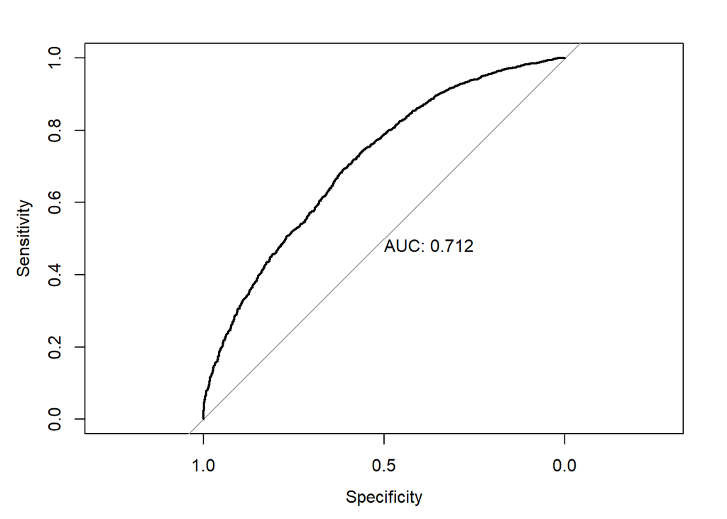

```r
eme_fit.ridge.roc <- roc(y_test ~ eme_fit.ridge.pred, plot = TRUE,
                         print.auc = TRUE)
```

See the result:

```r
eme_fit.ridge.roc.bmetrics <- coords(eme_fit.ridge.roc, x="best", ret="all")
eme_fit.ridge.roc.bmetrics
```

```
##           threshold specificity sensitivity  accuracy  tn   tp   fn  fp
## threshold   0.71982   0.6150327   0.6899913 0.6713309 941 3185 1431 589
##                 npv       ppv       fdr       fpr       tpr       tnr       fnr
## threshold 0.3967116 0.8439322 0.1560678 0.3849673 0.6899913 0.6150327 0.3100087
##           1-specificity 1-sensitivity 1-accuracy     1-npv     1-ppv precision
## threshold     0.3849673     0.3100087  0.3286691 0.6032884 0.1560678 0.8439322
##              recall   youden closest.topleft
## threshold 0.6899913 1.305024       0.2443052
```

See the confusion matrix using the best threshold value.

```r
table(preds=(eme_fit.ridge.pred > eme_fit.ridge.roc.bmetrics$threshold), true=as.logical(cl_emerg_min_fd.test$fast_emergency))
```

```
##        true
## preds   FALSE TRUE
##   FALSE   941 1431
##   TRUE    589 3185
```

Concatenate with the other results.

```r
row.names(eme_fit.ridge.roc.bmetrics) <- "Full Moldel Ridge"
eme_results <- rbind(eme_results, eme_fit.ridge.roc.bmetrics)
```

## 4.5 Lasso Shrinkage Estimation

Now is the turn of lasso and we decide to use again the full model for the same reason of ridge.

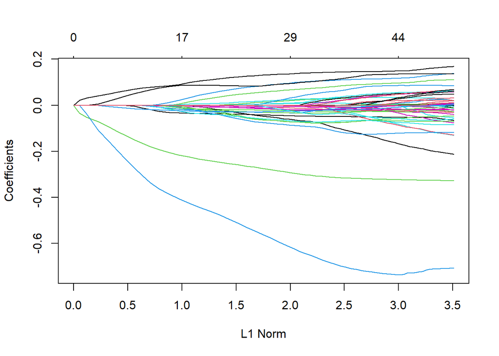

```r
eme_fit.lasso <- glmnet(x_train, y_train, familiy="binomial", alpha = 1)
plot(eme_fit.lasso)
```

Again choose the best lambda via cross-validation.

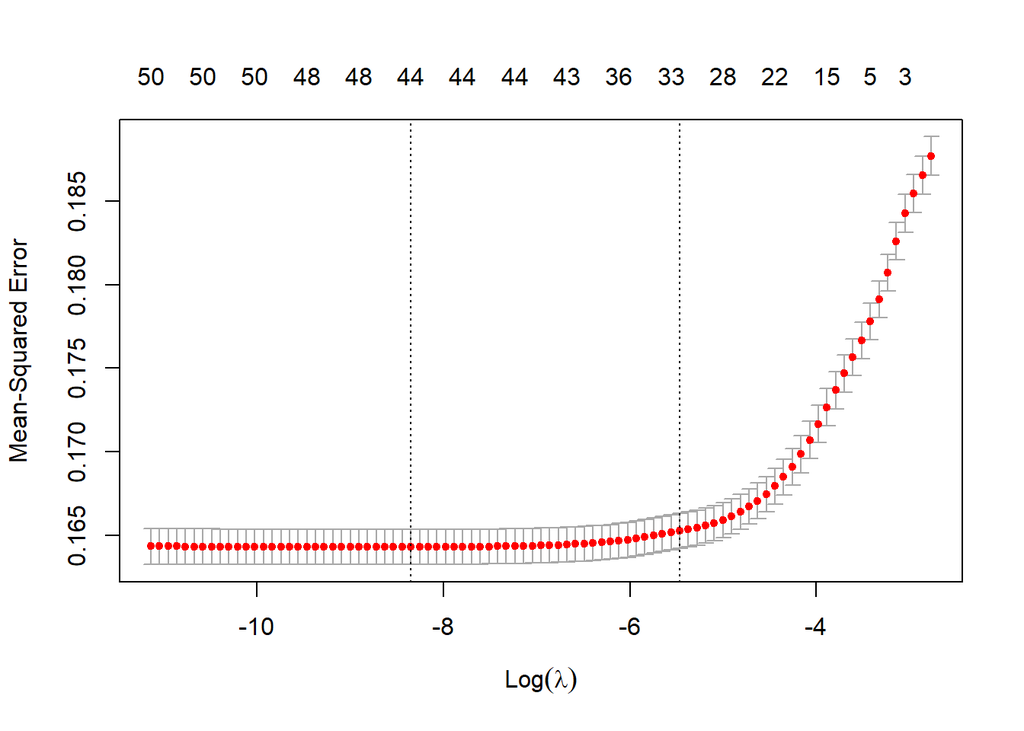

```r
eme_cv.lasso <- cv.glmnet(x_train, y_train, familiy="binomial", alpha = 1)
plot(eme_cv.lasso)
```

The value of $\lambda$ that minimizes the ridge cross-validated mean square error is:

```r
eme_cv.lasso$lambda.min
```

```
## [1] 0.0002365465
```

Again like before we take as $\lambda$ value corresponding to one standard error from the minimum of the cross-validated mean square error:

```r
eme_bestlam.lasso <- eme_cv.lasso$lambda.1se
eme_bestlam.lasso
```

```
## [1] 0.004230988
```

Like before, now visualize again the lasso estimates as a function of the logarithm of $\lambda$ and add a vertical line corresponding to **best.lambda**:

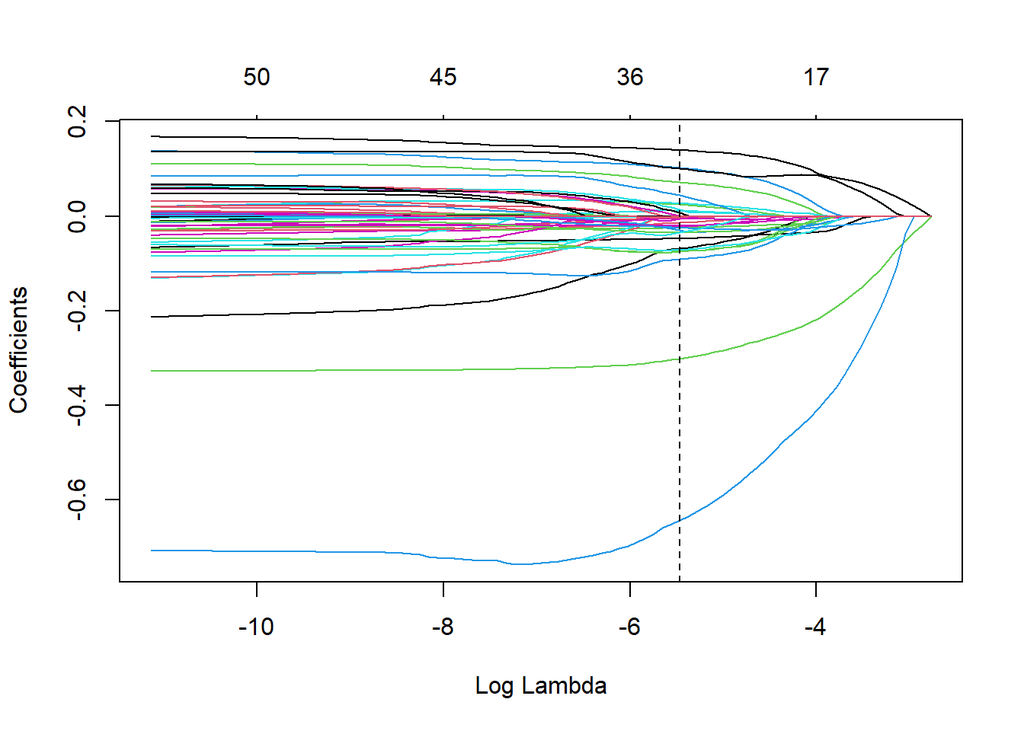

```r
plot(eme_fit.lasso, xvar = "lambda")
abline(v = log(eme_bestlam.lasso), lwd = 1.2, lty = "dashed")
```

These are the coefficients:

```r
eme_bestlam.lasso.coef <- coef(eme_fit.lasso,  s=eme_bestlam.lasso)

eme_bestlam.lasso.coef[eme_bestlam.lasso.coef[,1]!=0,]
```

```
##                                (Intercept)
##                               1.003260e+00
##                        inc_boroughBrooklyn
##                               1.395527e-01
##                          inc_boroughQueens
##                               7.237746e-02
##                   inc_boroughStaten Island
##                               1.018407e-01
##                                 cong_dist5
##                               1.091569e-02
##                                 cong_dist9
##                               2.436152e-02
##                                cong_dist11
##                               2.721578e-02
##                                cong_dist13
##                              -4.726560e-02
##                                cong_dist14
##                              -1.414157e-02
##                                cong_dist15
##                              -2.489558e-02
##                          al_source_descEMS
##                              -1.354913e-03
##                       al_source_descOthers
##                              -6.825766e-02
##                 al_index_descInitial Alarm
##                              -3.016039e-01
##                        al_index_descOthers
##                              -6.436074e-01
##                      inc_class_groupM_MFAs
##                               4.194108e-05
##                      inc_class_groupNonM_E
##                               1.002092e-01
##                      inc_class_groupNonS_F
##                              -7.503005e-02
##                         inc_class_groupS_F
##                               4.397334e-02
##                            inc_resp_min_qy
##                              -2.099287e-03
##                           engines_assigned
##                              -5.284552e-03
```

[output cut: 11 more lines]

```
##                              -7.345774e-02
##     al_source_descEMS-911:engines_assigned
##                              -9.055753e-02
##      al_source_descOthers:engines_assigned
##                              -7.081975e-02
##       al_source_descPHONE:engines_assigned
##                              -2.313600e-02
## al_source_descOthers:others_units_assigned
##                              -3.431902e-02
##  al_source_descPHONE:others_units_assigned
##                              -2.465702e-02
##         al_source_descEMS:ladders_assigned
##                              -3.472369e-02
##     al_source_descEMS-911:ladders_assigned
##                              -6.274513e-03
```

Now we apply prediction on the test set.

```r
eme_fit.lasso.pred <- predict(eme_fit.lasso, s = eme_bestlam.lasso,
                              newx = x_test, type = "response")
```

Then we apply the `roc` function to obtain the best threshold value.

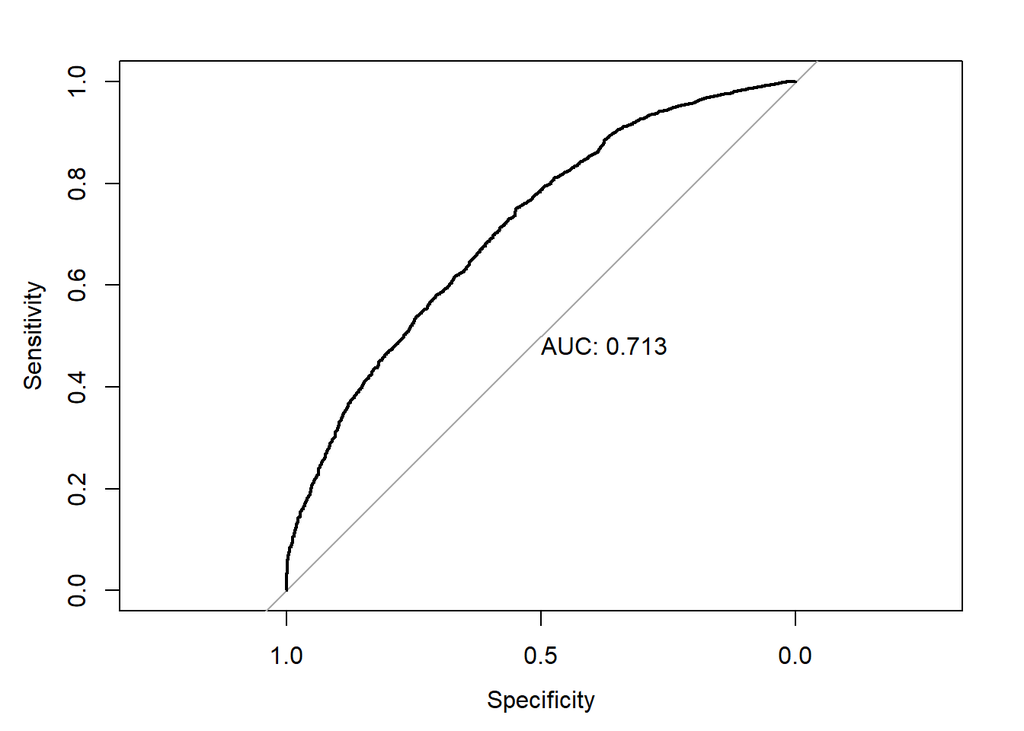

```r
eme_fit.lasso.roc <- roc(y_test ~ eme_fit.lasso.pred, plot = TRUE,
                         print.auc = TRUE)
```

See the result.

```r
eme_fit.lasso.roc.bmetrics <- coords(eme_fit.lasso.roc, x="best", ret="all")
eme_fit.lasso.roc.bmetrics
```

```
##           threshold specificity sensitivity  accuracy  tn   tp   fn  fp
## threshold 0.6986278   0.5490196   0.7508666 0.7006183 840 3466 1150 690
##                 npv      ppv      fdr       fpr       tpr       tnr       fnr
## threshold 0.4221106 0.833975 0.166025 0.4509804 0.7508666 0.5490196 0.2491334
##           1-specificity 1-sensitivity 1-accuracy     1-npv    1-ppv precision
## threshold     0.4509804     0.2491334  0.2993817 0.5778894 0.166025  0.833975
##              recall   youden closest.topleft
## threshold 0.7508666 1.299886       0.2654508
```

See the confusion matrix using the best threshold value.

```r
table(preds=(eme_fit.lasso.pred > eme_fit.lasso.roc.bmetrics$threshold), true=as.logical(cl_resp_min_fd.test$fast_response))
```

[output not shown]

Concatenate with the other results.

```r
row.names(eme_fit.lasso.roc.bmetrics) <- "Full Moldel Lasso"
eme_results <- rbind(eme_results, eme_fit.lasso.roc.bmetrics)
```

## 4.6 Linear Discriminant Analysis

Now we are going to deal with **LDA** or **Linear Discriminant Analysis**. For this type of Generative Model we decide to again to use the interaction full model.

LDA assumes that the data is normally distributed which is no our case, however we have decided to estimate its performance in any case.

```r
eme_lda.fit <- lda(formula(eme_glm.full.inter), data = cl_emerg_min_fd.train)
eme_lda.fit
```

```
## Call:
## lda(formula(eme_glm.full.inter), data = cl_emerg_min_fd.train)
##
## Prior probabilities of groups:
##     FALSE      TRUE
## 0.2505289 0.7494711
##
## Group means:
##       inc_boroughBrooklyn inc_boroughManhattan inc_boroughQueens
## FALSE           0.1888600            0.2968496         0.1888600
## TRUE            0.3410596            0.2176202         0.2054066
##       inc_boroughStaten Island cong_dist5 cong_dist6 cong_dist7 cong_dist8
## FALSE               0.03637545 0.06804157 0.05082819 0.06999026  0.0691783
## TRUE                0.05417436 0.08213006 0.04782325 0.10411465  0.1114428
##       cong_dist9 cong_dist10 cong_dist11 cong_dist12 cong_dist13 cong_dist14
## FALSE 0.03751218  0.09548555  0.04774277  0.11253654  0.16222800  0.09840857
## TRUE  0.08636413  0.10748019  0.07415047  0.08924112  0.09830637  0.06969927
##       cong_dist15 cong_dist16 al_source_descEMS al_source_descEMS-911
## FALSE   0.1635271 0.010880156         0.2884053             0.1713219
## TRUE    0.1055803 0.007871024         0.2244056             0.1316904
##       al_source_descOthers al_source_descPHONE al_index_descInitial Alarm
## FALSE           0.03458915           0.4088990                  0.9753167
## TRUE            0.01981327           0.4482141                  0.8749864
##       al_index_descOthers highest_al_levelNonFirst Alarm inc_class_groupM_MFAs
## FALSE          0.01558948                     0.01364079          0.0001623904
## TRUE           0.00000000                     0.00000000          0.0062425361
##       inc_class_groupNonM_E inc_class_groupNonM_MFAs inc_class_groupNonS_F
## FALSE             0.4582657             0.0009743423            0.03052939
## TRUE              0.5609054             0.0384323092            0.01302790
##       inc_class_groupS_F inc_resp_min_qy engines_assigned ladders_assigned
## FALSE         0.06138357        6.040178         1.292465        0.7830464
## TRUE          0.04353490        5.919488         1.099881        0.7803170
##       others_units_assigned day_typeWeekend working_hourTRUE time_of_dayEvening
## FALSE             0.5472556       0.2658331        0.6399805          0.1974667
## TRUE              0.3440994       0.2735859        0.5699164          0.2483444
##       time_of_dayMorning time_of_dayNight tua_is_oneTRUE
## FALSE          0.3077298        0.1276388      0.5828191
## TRUE           0.2603409        0.1523722      0.5759418
##       al_source_descEMS:engines_assigned al_source_descEMS-911:engines_assigned
## FALSE                          0.2843456                              0.1760312
```

[output cut: 66 more lines]

```
## time_of_dayMorning                          -0.139475512
## time_of_dayNight                             0.418498064
## tua_is_oneTRUE                               0.461173054
## al_source_descEMS:engines_assigned          -0.321373019
## al_source_descEMS-911:engines_assigned      -0.830128821
## al_source_descOthers:engines_assigned       -0.611986663
## al_source_descPHONE:engines_assigned        -0.001116411
## al_source_descEMS:others_units_assigned      0.343494658
## al_source_descEMS-911:others_units_assigned  0.223443188
## al_source_descOthers:others_units_assigned  -0.067086436
## al_source_descPHONE:others_units_assigned    0.010844132
## al_source_descEMS:ladders_assigned          -0.368224703
## al_source_descEMS-911:ladders_assigned       0.121462491
## al_source_descOthers:ladders_assigned        0.528438141
## al_source_descPHONE:ladders_assigned         0.134811744
```

An example of group mean is the mean engines assigned to slow emergencies.

```r
with(cl_emerg_min_fd.train,
     mean(engines_assigned[fast_emergency == FALSE]))
```

```
## [1] 1.292465
```

Now we make the prediction on the test set.

```r
eme_lda.preds <- predict(eme_lda.fit, newdata = cl_emerg_min_fd.test,
                         type = "response")
```

The ROC curve for linear discriminant analysis is:

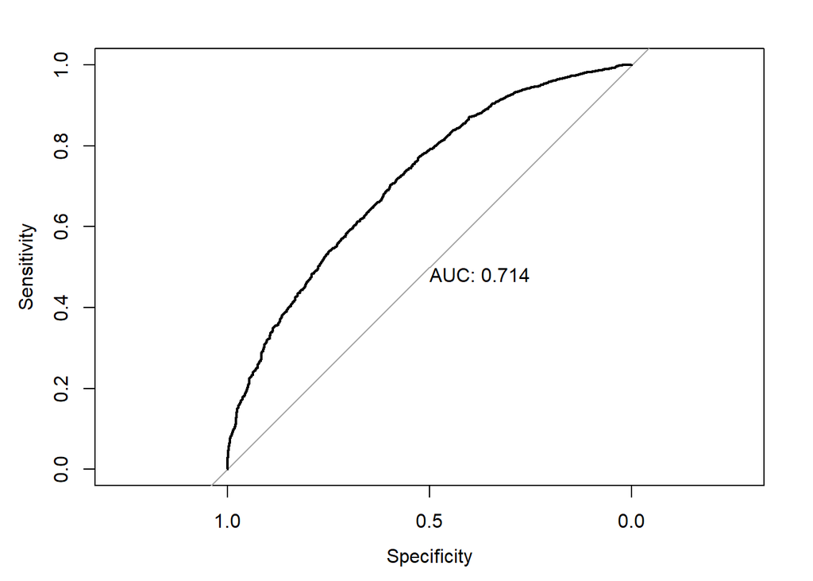

```r
eme_lda.roc <- roc(
  cl_emerg_min_fd.test$fast_emergency ~ eme_lda.preds$posterior[, 2],
  plot = TRUE, print.auc = TRUE)
```

The best choice for the threshold of linear discriminant analysis yields an accuracy of:

```r
eme_lda.roc.bmetrics <- coords(eme_lda.roc, x = "best", ret = "all")
eme_lda.roc.bmetrics
```

```
##           threshold specificity sensitivity accuracy  tn   tp   fn  fp
## threshold 0.7334754    0.596732   0.7034229 0.676863 913 3247 1369 617
##                 npv       ppv       fdr      fpr       tpr      tnr       fnr
## threshold 0.4000876 0.8403209 0.1596791 0.403268 0.7034229 0.596732 0.2965771
##           1-specificity 1-sensitivity 1-accuracy     1-npv     1-ppv precision
## threshold      0.403268     0.2965771   0.323137 0.5999124 0.1596791 0.8403209
##              recall   youden closest.topleft
## threshold 0.7034229 1.300155        0.250583
```

See the confusion matrix using the best threshold value.

```r
table(preds=(eme_lda.preds$posterior[, 2] > eme_lda.roc.bmetrics$threshold),
      true=as.logical(cl_emerg_min_fd.test$fast_emergency))
```

```
##        true
## preds   FALSE TRUE
##   FALSE   913 1369
##   TRUE    617 3247
```

Concatenate with the other results.

```r
row.names(eme_lda.roc.bmetrics) <- "Linear Discriminant Analysis"
eme_results <- rbind(eme_results, eme_lda.roc.bmetrics)
```

## 4.7 Naive Baye

Continuing with the analysis we try **Naive Bayes** algorithm. In this case we can’t use a model with interaction term since Naive Bayes do not support these relations. Thus we decide to use the **Full Model**.

Note that Naive Bayes assumes all predictors being independent to each other.

```r
eme_nb.fit <- naiveBayes(formula(eme_glm.full), data = cl_emerg_min_fd.train)
eme_nb.fit
```

```
##
## Naive Bayes Classifier for Discrete Predictors
##
## Call:
## naiveBayes.default(x = X, y = Y, laplace = laplace)
##
## A-priori probabilities:
## Y
##     FALSE      TRUE
## 0.2505289 0.7494711
##
## Conditional probabilities:
##        inc_borough
## Y            Bronx   Brooklyn  Manhattan     Queens Staten Island
##   FALSE 0.28905489 0.18886002 0.29684963 0.18886002    0.03637545
##   TRUE  0.18173922 0.34105960 0.21762024 0.20540658    0.05417436
##
##        cong_dist
## Y                 3           5           6           7           8           9
##   FALSE 0.013640792 0.068041572 0.050828191 0.069990257 0.069178305 0.037512179
##   TRUE  0.015796330 0.082130062 0.047823255 0.104114646 0.111442840 0.086364130
##        cong_dist
## Y                10          11          12          13          14          15
##   FALSE 0.095485547 0.047742774 0.112536538 0.162227996 0.098408574 0.163527119
##   TRUE  0.107480187 0.074150472 0.089241125 0.098306373 0.069699273 0.105580284
##        cong_dist
## Y                16
##   FALSE 0.010880156
##   TRUE  0.007871024
##
##        al_source_desc
## Y          CLASS-3        EMS    EMS-911     Others      PHONE
##   FALSE 0.09678467 0.28840533 0.17132186 0.03458915 0.40889899
##   TRUE  0.17587667 0.22440560 0.13169037 0.01981327 0.44821409
##
##        al_index_desc
## Y       DEFAULT RECORD Initial Alarm      Others
##   FALSE    0.009093862   0.975316661 0.015589477
##   TRUE     0.125013571   0.874986429 0.000000000
##
```

[output cut: 38 more lines]

```
##
##        working_hour
## Y           FALSE      TRUE
##   FALSE 0.3600195 0.6399805
##   TRUE  0.4300836 0.5699164
##
##        time_of_day
## Y       Afternoon   Evening   Morning     Night
##   FALSE 0.3671647 0.1974667 0.3077298 0.1276388
##   TRUE  0.3389426 0.2483444 0.2603409 0.1523722
##
##        tua_is_one
## Y           FALSE      TRUE
##   FALSE 0.4171809 0.5828191
##   TRUE  0.4240582 0.5759418
```

An example of conditional probabilities of `al_index_desc` for slow response time are:

```r
with(cl_emerg_min_fd.train, table(al_index_desc[fast_emergency == FALSE]) /
       sum(fast_emergency == FALSE))
```

```
##
## DEFAULT RECORD  Initial Alarm         Others
##    0.009093862    0.975316661    0.015589477
```

The mean and standard deviations of `inc_resp_min_qy` conditional to the emergency time taken are:

```r
with(cl_emerg_min_fd.train,
     mean(inc_resp_min_qy[fast_emergency == FALSE]))
```

```
## [1] 6.040178
```

```r
with(cl_emerg_min_fd.train,
     sd(inc_resp_min_qy[fast_emergency == FALSE]))
```

```
## [1] 2.680952
```

```r
with(cl_emerg_min_fd.train,
     mean(inc_resp_min_qy[fast_emergency == TRUE]))
```

```
## [1] 5.919488
```

```r
with(cl_emerg_min_fd.train,
     sd(inc_resp_min_qy[fast_emergency == TRUE]))
```

```
## [1] 2.733963
```

Prediction for the test set:

```r
eme_nb.preds <- predict(eme_nb.fit, newdata = cl_emerg_min_fd.test)
```

Predicted class probabilities can be obtained using the argument **type = “raw”**:

```r
eme_nb.posterior <- predict(eme_nb.fit, newdata = cl_emerg_min_fd.test,
                            type = "raw")
head(eme_nb.posterior)
```

```
##           FALSE      TRUE
## [1,] 0.14710728 0.8528927
## [2,] 0.25697142 0.7430286
## [3,] 0.44220200 0.5577980
## [4,] 0.07129849 0.9287015
## [5,] 0.01835906 0.9816409
## [6,] 0.10937198 0.8906280
```

ROC curve:

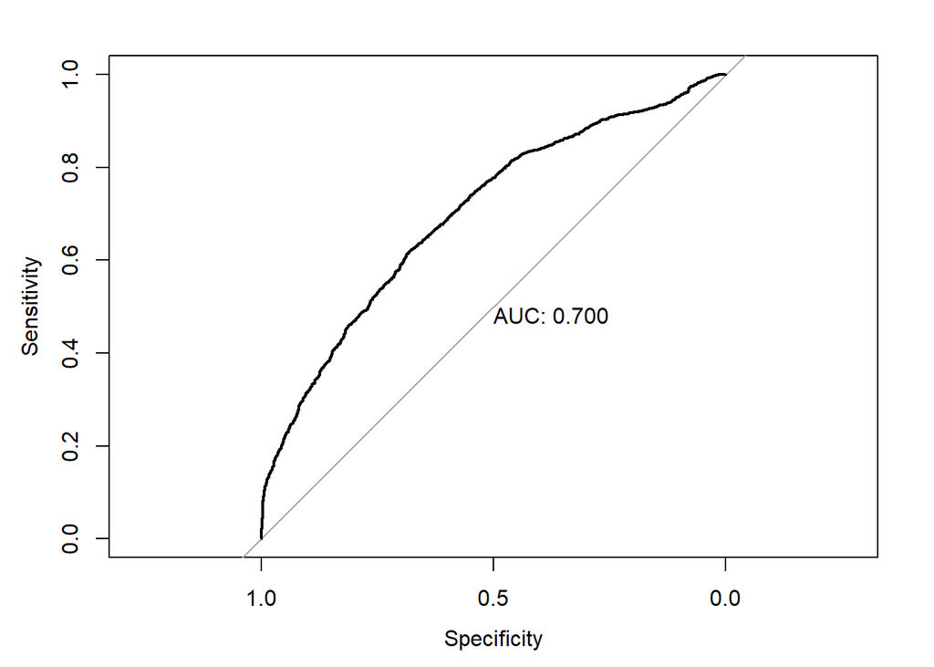

```r
eme_nb.roc <- roc(cl_emerg_min_fd.test$fast_emergency ~ eme_nb.posterior[, 2],
                  plot = TRUE, print.auc = TRUE)
```

```r
eme_nb.roc.bmetrics <- coords(eme_nb.roc, x = "best", ret = "all")
eme_nb.roc.bmetrics
```

```
##           threshold specificity sensitivity  accuracy   tn   tp   fn  fp
## threshold 0.8648093   0.6803922    0.620234 0.6352099 1041 2863 1753 489
##                 npv       ppv       fdr       fpr      tpr       tnr      fnr
## threshold 0.3725841 0.8541169 0.1458831 0.3196078 0.620234 0.6803922 0.379766
##           1-specificity 1-sensitivity 1-accuracy     1-npv     1-ppv precision
## threshold     0.3196078      0.379766  0.3647901 0.6274159 0.1458831 0.8541169
##             recall   youden closest.topleft
## threshold 0.620234 1.300626       0.2463714
```

See the confusion matrix using the best threshold value.

```r
table(preds=(eme_nb.posterior[, 2] > eme_nb.roc.bmetrics$threshold),
      true=as.logical(cl_emerg_min_fd.test$fast_emergency))
```

```
##        true
## preds   FALSE TRUE
##   FALSE  1041 1753
##   TRUE    489 2863
```

```r
row.names(eme_nb.roc.bmetrics) <- "Naive Bayes"
eme_results <- rbind(eme_results, eme_nb.roc.bmetrics)
```

## 4.8 Conclusion

Finally we make a recap of the final results that we have obtained.

```r
eme_results
```

```
##                              threshold specificity sensitivity  accuracy   tn
## Full Model                   0.7298004   0.6130719   0.6934575 0.6734461  938
## Interaction Full Model       0.7214309   0.5921569   0.7133882 0.6832086  906
## Cleaned Model                0.7088877   0.5326797   0.7642981 0.7066385  815
## Interaction Cleaned Model    0.7500159   0.6758170   0.6256499 0.6381386 1034
## Full Moldel Ridge            0.7198200   0.6150327   0.6899913 0.6713309  941
## Full Moldel Lasso            0.6986278   0.5490196   0.7508666 0.7006183  840
## Linear Discriminant Analysis 0.7334754   0.5967320   0.7034229 0.6768630  913
## Naive Bayes                  0.8648093   0.6803922   0.6202340 0.6352099 1041
##                                tp   fn  fp       npv       ppv       fdr
## Full Model                   3201 1415 592 0.3986400 0.8439230 0.1560770
## Interaction Full Model       3293 1323 624 0.4064603 0.8406944 0.1593056
## Cleaned Model                3528 1088 715 0.4282712 0.8314872 0.1685128
## Interaction Cleaned Model    2888 1728 496 0.3743664 0.8534279 0.1465721
## Full Moldel Ridge            3185 1431 589 0.3967116 0.8439322 0.1560678
## Full Moldel Lasso            3466 1150 690 0.4221106 0.8339750 0.1660250
## Linear Discriminant Analysis 3247 1369 617 0.4000876 0.8403209 0.1596791
## Naive Bayes                  2863 1753 489 0.3725841 0.8541169 0.1458831
##                                    fpr       tpr       tnr       fnr
## Full Model                   0.3869281 0.6934575 0.6130719 0.3065425
## Interaction Full Model       0.4078431 0.7133882 0.5921569 0.2866118
## Cleaned Model                0.4673203 0.7642981 0.5326797 0.2357019
## Interaction Cleaned Model    0.3241830 0.6256499 0.6758170 0.3743501
## Full Moldel Ridge            0.3849673 0.6899913 0.6150327 0.3100087
## Full Moldel Lasso            0.4509804 0.7508666 0.5490196 0.2491334
## Linear Discriminant Analysis 0.4032680 0.7034229 0.5967320 0.2965771
## Naive Bayes                  0.3196078 0.6202340 0.6803922 0.3797660
##                              1-specificity 1-sensitivity 1-accuracy     1-npv
## Full Model                       0.3869281     0.3065425  0.3265539 0.6013600
## Interaction Full Model           0.4078431     0.2866118  0.3167914 0.5935397
## Cleaned Model                    0.4673203     0.2357019  0.2933615 0.5717288
## Interaction Cleaned Model        0.3241830     0.3743501  0.3618614 0.6256336
## Full Moldel Ridge                0.3849673     0.3100087  0.3286691 0.6032884
## Full Moldel Lasso                0.4509804     0.2491334  0.2993817 0.5778894
## Linear Discriminant Analysis     0.4032680     0.2965771  0.3231370 0.5999124
## Naive Bayes                      0.3196078     0.3797660  0.3647901 0.6274159
##                                  1-ppv precision    recall   youden
## Full Model                   0.1560770 0.8439230 0.6934575 1.306529
## Interaction Full Model       0.1593056 0.8406944 0.7133882 1.305545
## Cleaned Model                0.1685128 0.8314872 0.7642981 1.296978
## Interaction Cleaned Model    0.1465721 0.8534279 0.6256499 1.301467
## Full Moldel Ridge            0.1560678 0.8439322 0.6899913 1.305024
## Full Moldel Lasso            0.1660250 0.8339750 0.7508666 1.299886
## Linear Discriminant Analysis 0.1596791 0.8403209 0.7034229 1.300155
## Naive Bayes                  0.1458831 0.8541169 0.6202340 1.300626
##                              closest.topleft
## Full Model                         0.2436816
## Interaction Full Model             0.2484823
## Cleaned Model                      0.2739436
## Interaction Cleaned Model          0.2452326
## Full Moldel Ridge                  0.2443052
## Full Moldel Lasso                  0.2654508
## Linear Discriminant Analysis       0.2505830
## Naive Bayes                        0.2463714
```

1. **Specificity**

```r
eme_results %>% select(specificity) %>% arrange(desc(specificity))
```

```
##                              specificity
## Naive Bayes                    0.6803922
## Interaction Cleaned Model      0.6758170
## Full Moldel Ridge              0.6150327
## Full Model                     0.6130719
## Linear Discriminant Analysis   0.5967320
## Interaction Full Model         0.5921569
## Full Moldel Lasso              0.5490196
## Cleaned Model                  0.5326797
```

For the specificity the best model is **Naive Bayes**.

2. **Sensitivity**

```r
eme_results %>% select(sensitivity) %>% arrange(desc(sensitivity))
```

```
##                              sensitivity
## Cleaned Model                  0.7642981
## Full Moldel Lasso              0.7508666
## Interaction Full Model         0.7133882
## Linear Discriminant Analysis   0.7034229
## Full Model                     0.6934575
## Full Moldel Ridge              0.6899913
## Interaction Cleaned Model      0.6256499
## Naive Bayes                    0.6202340
```

For sensitivity the best model is **Cleaned Model**.

3. **Accuracy**

```r
eme_results %>% select(accuracy) %>% arrange(desc(accuracy))
```

```
##                               accuracy
## Cleaned Model                0.7066385
## Full Moldel Lasso            0.7006183
## Interaction Full Model       0.6832086
## Linear Discriminant Analysis 0.6768630
## Full Model                   0.6734461
## Full Moldel Ridge            0.6713309
## Interaction Cleaned Model    0.6381386
## Naive Bayes                  0.6352099
```

Finally regarding the accuracy measure the best model is again the **Cleaned Model**.

In conclusion we say that the best model for this analysis is the **Cleaned Model**, so what we have discussed previously remains true. To recall we opt for this model since we are again in an unbalanced case regarding the response, thus we have to prefer a model that is able to correctly predict fast emergencies being those emergencies actually fast (so high sensitivity). But of course maintaining an eye on the specificity measure.

# 5 Special Thanks

If you are arrived up here, I would like to thank you for your time, I hope that the analysis were interesting to read.